# scDART-seq_m6A_dataset

### calculate the error rate for site

```r
# calculate teh meta_error_rate for each site

## isoform
error_reads_list_isoform_YTH <-
  readRDS("/gpfs/work/bio/haozhewang17/data/VeloRM_data/pre_process/error_reads_list_isoform_YTH.rds")

error_reads_list_isoform_YTH_sum <- Reduce("+", error_reads_list_isoform_YTH)

reads_counts_isoform_YTH <-
  readRDS("/gpfs/work/bio/haozhewang17/data/VeloRM_data/pre_process/reads_counts_isoform_YTH.rds")

summed_vectors_list <- lapply(reads_counts_isoform_YTH, function(df) rowSums(df))

reads_counts_isoform_YTH_sum <- Reduce("+", summed_vectors_list)

error_rate_meta_isoform_YTH <- error_reads_list_isoform_YTH_sum/
  (error_reads_list_isoform_YTH_sum+reads_counts_isoform_YTH_sum)



error_reads_list_isoform_YTHmut <-
  readRDS("/gpfs/work/bio/haozhewang17/data/VeloRM_data/pre_process/error_reads_list_isoform_YTHmut.rds")

error_reads_list_isoform_YTHmut_sum <- Reduce("+", error_reads_list_isoform_YTHmut)

reads_counts_isoform_YTHmut <-
  readRDS("/gpfs/work/bio/haozhewang17/data/VeloRM_data/pre_process/reads_counts_isoform_YTHmut.rds")

summed_vectors_list <- lapply(reads_counts_isoform_YTHmut, function(df) rowSums(df))

reads_counts_isoform_YTHmut_sum <- Reduce("+", summed_vectors_list)

error_rate_meta_isoform_YTHmut <- error_reads_list_isoform_YTHmut_sum/
  (error_reads_list_isoform_YTHmut_sum+reads_counts_isoform_YTHmut_sum)


error_rate_meta_isoform <- (error_reads_list_isoform_YTHmut_sum+error_reads_list_isoform_YTH_sum)/
  (error_reads_list_isoform_YTHmut_sum+reads_counts_isoform_YTHmut_sum+
     error_reads_list_isoform_YTH_sum+reads_counts_isoform_YTH_sum)

saveRDS(error_rate_meta_isoform_YTH,"/gpfs/work/bio/haozhewang17/data/VeloRM_data/pre_process/error_rate_meta_isoform_YTH.rds")
saveRDS(error_rate_meta_isoform_YTHmut,"/gpfs/work/bio/haozhewang17/data/VeloRM_data/pre_process/error_rate_meta_isoform_YTHmut.rds")
saveRDS(error_rate_meta_isoform,"/gpfs/work/bio/haozhewang17/data/VeloRM_data/pre_process/error_rate_meta_isoform.rds")

## spliced

rm(list = ls())
gc()
error_reads_list_spliced_YTH <-
  readRDS("/gpfs/work/bio/haozhewang17/data/VeloRM_data/pre_process/error_reads_list_spliced_YTH.rds")

error_reads_list_spliced_YTH_sum <- Reduce("+", error_reads_list_spliced_YTH)

reads_counts_spliced_YTH <-
  readRDS("/gpfs/work/bio/haozhewang17/data/VeloRM_data/pre_process/reads_counts_spliced_YTH.rds")

summed_vectors_list <- lapply(reads_counts_spliced_YTH, function(df) rowSums(df))

reads_counts_spliced_YTH_sum <- Reduce("+", summed_vectors_list)

error_rate_meta_spliced_YTH <- error_reads_list_spliced_YTH_sum/
  (error_reads_list_spliced_YTH_sum+reads_counts_spliced_YTH_sum)



error_reads_list_spliced_YTHmut <-
  readRDS("/gpfs/work/bio/haozhewang17/data/VeloRM_data/pre_process/error_reads_list_spliced_YTHmut.rds")

error_reads_list_spliced_YTHmut_sum <- Reduce("+", error_reads_list_spliced_YTHmut)

reads_counts_spliced_YTHmut <-
  readRDS("/gpfs/work/bio/haozhewang17/data/VeloRM_data/pre_process/reads_counts_spliced_YTHmut.rds")

summed_vectors_list <- lapply(reads_counts_spliced_YTHmut, function(df) rowSums(df))

reads_counts_spliced_YTHmut_sum <- Reduce("+", summed_vectors_list)

error_rate_meta_spliced_YTHmut <- error_reads_list_spliced_YTHmut_sum/
  (error_reads_list_spliced_YTHmut_sum+reads_counts_spliced_YTHmut_sum)


error_rate_meta_spliced <- (error_reads_list_spliced_YTHmut_sum+error_reads_list_spliced_YTH_sum)/
  (error_reads_list_spliced_YTHmut_sum+reads_counts_spliced_YTHmut_sum+
     error_reads_list_spliced_YTH_sum+reads_counts_spliced_YTH_sum)

saveRDS(error_rate_meta_spliced_YTH,"/gpfs/work/bio/haozhewang17/data/VeloRM_data/pre_process/error_rate_meta_spliced_YTH.rds")
saveRDS(error_rate_meta_spliced_YTHmut,"/gpfs/work/bio/haozhewang17/data/VeloRM_data/pre_process/error_rate_meta_spliced_YTHmut.rds")
saveRDS(error_rate_meta_spliced,"/gpfs/work/bio/haozhewang17/data/VeloRM_data/pre_process/error_rate_meta_spliced.rds")
## pre


rm(list = ls())
gc()
error_reads_list_pre_YTH <-
  readRDS("/gpfs/work/bio/haozhewang17/data/VeloRM_data/pre_process/error_reads_list_pre_YTH.rds")

error_reads_list_pre_YTH_sum <- Reduce("+", error_reads_list_pre_YTH)

reads_counts_pre_YTH <-
  readRDS("/gpfs/work/bio/haozhewang17/data/VeloRM_data/pre_process/reads_counts_pre_YTH.rds")

summed_vectors_list <- lapply(reads_counts_pre_YTH, function(df) rowSums(df))

reads_counts_pre_YTH_sum <- Reduce("+", summed_vectors_list)

error_rate_meta_pre_YTH <- error_reads_list_pre_YTH_sum/
  (error_reads_list_pre_YTH_sum+reads_counts_pre_YTH_sum)



error_reads_list_pre_YTHmut <-
  readRDS("/gpfs/work/bio/haozhewang17/data/VeloRM_data/pre_process/error_reads_list_pre_YTHmut.rds")

error_reads_list_pre_YTHmut_sum <- Reduce("+", error_reads_list_pre_YTHmut)

reads_counts_pre_YTHmut <-
  readRDS("/gpfs/work/bio/haozhewang17/data/VeloRM_data/pre_process/reads_counts_pre_YTHmut.rds")

summed_vectors_list <- lapply(reads_counts_pre_YTHmut, function(df) rowSums(df))

reads_counts_pre_YTHmut_sum <- Reduce("+", summed_vectors_list)

error_rate_meta_pre_YTHmut <- error_reads_list_pre_YTHmut_sum/
  (error_reads_list_pre_YTHmut_sum+reads_counts_pre_YTHmut_sum)


error_rate_meta_pre <- (error_reads_list_pre_YTHmut_sum+error_reads_list_pre_YTH_sum)/
  (error_reads_list_pre_YTHmut_sum+reads_counts_pre_YTHmut_sum+
     error_reads_list_pre_YTH_sum+reads_counts_pre_YTH_sum)

saveRDS(error_rate_meta_pre_YTH,"/gpfs/work/bio/haozhewang17/data/VeloRM_data/pre_process/error_rate_meta_pre_YTH.rds")
saveRDS(error_rate_meta_pre_YTHmut,"/gpfs/work/bio/haozhewang17/data/VeloRM_data/pre_process/error_rate_meta_pre_YTHmut.rds")
saveRDS(error_rate_meta_pre,"/gpfs/work/bio/haozhewang17/data/VeloRM_data/pre_process/error_rate_meta_pre.rds")
```

### filter the site

From 1,599 cells (1,209 test cells and 390 YTH domain-mutated negative controls), we initially extracted 2,371,331 candidate sites. We applied stringent quality filters, excluding sites with either: (1) an error rate exceeding 1%, or (2) median read coverage below 10 in spliced mRNA or unspliced mRNA. This yielded 37,199 high-confidence m6A sites for downstream analysis.

```r
# Load necessary library
library(VeloRM)

# Read metadata
error_rate_meta_spliced <- readRDS("/gpfs/work/bio/haozhewang17/data/VeloRM_data/pre_process/error_rate_meta_spliced.rds")
error_rate_meta_pre <- readRDS("/gpfs/work/bio/haozhewang17/data/VeloRM_data/pre_process/error_rate_meta_pre.rds")
index_error <- intersect(which(error_rate_meta_spliced <= 0.01), which(error_rate_meta_pre <= 0.01))

# Free up memory
rm(error_rate_meta_spliced, error_rate_meta_pre)
gc()

# Read counts
reads_counts_spliced_YTHmut <- readRDS("/gpfs/work/bio/haozhewang17/data/VeloRM_data/pre_process/reads_counts_spliced_YTHmut.rds")
reads_counts_spliced_YTH <- readRDS("/gpfs/work/bio/haozhewang17/data/VeloRM_data/pre_process/reads_counts_spliced_YTH.rds")

# Process spliced data
spliced_meth_test <- as.data.frame(lapply(reads_counts_spliced_YTH, function(df) df[["methylated_reads"]]))
spliced_unmeth_test <- as.data.frame(lapply(reads_counts_spliced_YTH, function(df) df[["unmethylated_reads"]]))
spliced_meth_control <- as.data.frame(lapply(reads_counts_spliced_YTHmut, function(df) df[["methylated_reads"]]))
spliced_unmeth_control <- as.data.frame(lapply(reads_counts_spliced_YTHmut, function(df) df[["unmethylated_reads"]]))

# Free up memory
rm(reads_counts_spliced_YTH, reads_counts_spliced_YTHmut)
gc()

reads_counts_pre_YTHmut <- readRDS("/gpfs/work/bio/haozhewang17/data/VeloRM_data/pre_process/reads_counts_pre_YTHmut.rds")
reads_counts_pre_YTH <- readRDS("/gpfs/work/bio/haozhewang17/data/VeloRM_data/pre_process/reads_counts_pre_YTH.rds")

# Process pre-mRNA data
pre_meth_test <- as.data.frame(lapply(reads_counts_pre_YTH, function(df) df[["methylated_reads"]]))
pre_unmeth_test <- as.data.frame(lapply(reads_counts_pre_YTH, function(df) df[["unmethylated_reads"]]))
pre_meth_control <- as.data.frame(lapply(reads_counts_pre_YTHmut, function(df) df[["methylated_reads"]]))
pre_unmeth_control <- as.data.frame(lapply(reads_counts_pre_YTHmut, function(df) df[["unmethylated_reads"]]))

# Free up memory
rm(reads_counts_pre_YTH, reads_counts_pre_YTHmut)
gc()

# Set row names
rownames(spliced_meth_test) <- rownames(spliced_unmeth_test) <- rownames(spliced_meth_control) <-
  rownames(spliced_unmeth_control) <- paste0("site_", 1:dim(spliced_unmeth_test)[1])

rownames(pre_meth_test) <- rownames(pre_unmeth_test) <- rownames(pre_meth_control) <-
  rownames(pre_unmeth_control) <- paste0("site_", 1:dim(pre_unmeth_test)[1])

# Calculate spliced and pre-mRNA test matrices
spliced_test <- cbind(spliced_meth_test, spliced_meth_control) + cbind(spliced_unmeth_test, spliced_unmeth_control)


pre_test <- cbind(pre_meth_test, pre_meth_control) + cbind(pre_unmeth_test, pre_unmeth_control)


# Compute medians
spliced_median <- apply(spliced_test, 1, function(x) median(x, na.rm = TRUE))
rm(spliced_test)
gc()

pre_median <- apply(pre_test, 1, function(x) median(x, na.rm = TRUE))
rm(pre_test)
gc()

# Find common indices
index_median <- intersect(which(spliced_median >= 10), which(pre_median >= 10))

gc()



index <- intersect(index_error,index_median)

spliced_meth_test <- spliced_meth_test[index,]
spliced_unmeth_test <- spliced_unmeth_test[index,]
pre_meth_test <- pre_meth_test[index,]
pre_unmeth_test <- pre_unmeth_test[index,]

spliced_meth_control <- spliced_meth_control[index,]
spliced_unmeth_control <- spliced_unmeth_control[index,]
pre_meth_control <- pre_meth_control[index,]
pre_unmeth_control <- pre_unmeth_control[index,]


print("finish index")
saveRDS(spliced_median,"/gpfs/work/bio/haozhewang17/data/VeloRM_data/pre_process/spliced_median.rds")
saveRDS(pre_median,"/gpfs/work/bio/haozhewang17/data/VeloRM_data/pre_process/pre_median.rds")
saveRDS(index_median,"/gpfs/work/bio/haozhewang17/data/VeloRM_data/pre_process/index_median.rds")
saveRDS(index_error,"/gpfs/work/bio/haozhewang17/data/VeloRM_data/pre_process/index_error.rds")
saveRDS(index,"/gpfs/work/bio/haozhewang17/data/VeloRM_data/pre_process/index.rds")


reads_counts_isoform_YTHmut <- readRDS("/gpfs/work/bio/haozhewang17/data/velocity_finish_2/pre_process/reads_counts_pre_YTHmut.rds")
reads_counts_isoform_YTH <- readRDS("/gpfs/work/bio/haozhewang17/data/velocity_finish_2/pre_process/reads_counts_pre_YTH.rds")

# Process pre-mRNA data
isoform_meth_test <- as.data.frame(lapply(reads_counts_isoform_YTH, function(df) df[["methylated_reads"]]))
isoform_unmeth_test <- as.data.frame(lapply(reads_counts_isoform_YTH, function(df) df[["unmethylated_reads"]]))
isoform_meth_control <- as.data.frame(lapply(reads_counts_isoform_YTHmut, function(df) df[["methylated_reads"]]))
isoform_unmeth_control <- as.data.frame(lapply(reads_counts_isoform_YTHmut, function(df) df[["unmethylated_reads"]]))

rm(reads_counts_isoform_YTH, reads_counts_isoform_YTHmut)
gc()

rownames(isoform_meth_test) <- rownames(isoform_unmeth_test) <- rownames(isoform_meth_control) <-
  rownames(isoform_unmeth_control) <- paste0("site_", 1:dim(isoform_unmeth_test)[1])

isoform_meth_test <- isoform_meth_test[index,]
isoform_unmeth_test <- isoform_unmeth_test[index,]
isoform_meth_control <- isoform_meth_control[index,]
isoform_unmeth_control <- isoform_unmeth_control[index,]

test.list <- list(spliced_meth_test,spliced_unmeth_test,pre_meth_test,pre_unmeth_test,
                   isoform_meth_test,isoform_unmeth_test)
control.list <- list(spliced_meth_control,spliced_unmeth_control,pre_meth_control,
                      pre_unmeth_control,isoform_meth_control,isoform_unmeth_control)

res_preprocess <- methylation.sites.preprocess(test.list,control.list)

saveRDS(test.list,"/gpfs/work/bio/haozhewang17/data/VeloRM_data/pre_process/test.list.rds")
saveRDS(control.list,"/gpfs/work/bio/haozhewang17/data/VeloRM_data/pre_process/control.list.rds")
saveRDS(res_preprocess,"/gpfs/work/bio/haozhewang17/data/VeloRM_data/pre_process/res_preprocess.rds")

SNP <- readRDS("/gpfs/work/bio/haozhewang17/data/VeloRM_data/origin/SNP_all.rds")
SNP_index <- SNP[index]
saveRDS(SNP_index,"/gpfs/work/bio/haozhewang17/data/VeloRM_data/pre_process/SNP_37199.rds")
```

### DESeq2 to test the differential methylation between the spliced mRNA and pre-mRNA

```r
# Load input data
test.list <- readRDS("/gpfs/work/bio/haozhewang17/data/VeloRM_data/pre_process/test.list.rds")

# Extract different parts of the data
spliced.meth.test <- test.list[[1]]  # Methylated spliced data
spliced.unmeth.test <- test.list[[2]]  # Unmethylated spliced data
unspliced.meth.test <- test.list[[3]]  # Methylated unspliced data
unspliced.unmeth.test <- test.list[[4]]  # Unmethylated unspliced data

# Set random seed for reproducibility
set.seed(42)

# Record start time
start_time <- Sys.time()

# Load DESeq2 package
library(DESeq2)

# Define DESeq2 differential expression analysis function
DESeq2_test <- function(meth_control, meth_test, unmeth_control, unmeth_test) {
  # Convert input data to data frames
  meth_control <- data.frame(meth_control)
  meth_test <- data.frame(meth_test)
  unmeth_control <- data.frame(unmeth_control)
  unmeth_test <- data.frame(unmeth_test)

  # Function to calculate size factor
  sizeFactor <- function(data) {
    # Ensure data is not less than 0
    data <- as.matrix(data)

    # Log-transform the data
    log_data <- log(data)
    log_data[is.infinite(log_data)] <- NA
    log_mean <- rowMeans(log_data, na.rm = TRUE)
    log_s <- log_data - log_mean

    # Calculate size factor
    s_size <- exp(apply(log_s, 2, function(x) median(x, na.rm = TRUE)))
    return(s_size)
  }

  # Calculate size factors for spliced and unspliced data
  spliced_total <- meth_control + unmeth_control
  unspliced_total <- meth_test + unmeth_test

  spliced_size_factor <- sizeFactor(spliced_total)
  unspliced_size_factor <- sizeFactor(unspliced_total)

  # Get the number of control and test samples
  num_control <- dim(unmeth_control)[2]
  num_test <- dim(unmeth_test)[2]

  # Combine all data
  counts <- cbind(meth_control, meth_test, unmeth_control, unmeth_test)

  # Design the experiment matrix
  design = data.frame(
    Trt = rep(c(rep("control", num_control), rep("test", num_test)), 2),
    Meth = c(rep("meth", (num_control + num_test)), rep("unmeth", (num_control + num_test)))
  )

  # Define the model
  model = ~ Meth + Trt + Meth:Trt

  # Create DESeqDataSet object
  dds <- DESeqDataSetFromMatrix(countData = counts,
                                colData = design,
                                design = model)

  # Set size factors
  sizeFactors(dds) = rep(c(spliced_size_factor, unspliced_size_factor), 2)

  # Perform differential expression analysis
  dds <- DESeq(dds, test = "Wald")

  # Extract results
  res = DESeq2::results(dds, name = "Methunmeth.Trttest", cooksCutoff = FALSE)

  return(res)
}

# Call the function to perform differential expression analysis
result <- DESeq2_test(spliced.meth.test, unspliced.meth.test, spliced.unmeth.test, unspliced.unmeth.test)

# Record end time
end_time <- Sys.time()

# Print the runtime
print(end_time - start_time)


# Save the results
saveRDS(result, "/gpfs/work/bio/haozhewang17/data/VeloRM_data/pre_process/res_DESeq2.rds")
```

### SigRM to test the differential methylation between the test cell and control group

```r
test.list <- readRDS("/gpfs/work/bio/haozhewang17/data/VeloRM_data/pre_process/test.list.rds")
control.list <- readRDS("/gpfs/work/bio/haozhewang17/data/VeloRM_data/pre_process/control.list.rds")

## SigRM test
library(SigRM)

spliced.meth.test <- (test.list[[1]])
spliced.unmeth.test <- (test.list[[2]])
unspliced.meth.test <- (test.list[[3]])
unspliced.unmeth.test <- (test.list[[4]])
spliced.meth.control <- (control.list[[1]])
spliced.unmeth.control <- (control.list[[2]])
unspliced.meth.control <- (control.list[[3]])
unspliced.unmeth.control <- (control.list[[4]])


SigRMtest_res_spliced <- SigRMtest(spliced.meth.control,spliced.meth.test,
                                   spliced.unmeth.control,spliced.unmeth.test)

SigRMtest_res_unspliced <- SigRMtest(unspliced.meth.control,unspliced.meth.test,
                                     unspliced.unmeth.control,unspliced.unmeth.test)
saveRDS(SigRMtest_res_spliced,
        "/gpfs/work/bio/haozhewang17/data/VeloRM_data/pre_process/SigRMtest_res_spliced.rds")
saveRDS(SigRMtest_res_unspliced,
        "/gpfs/work/bio/haozhewang17/data/VeloRM_data/pre_process/SigRMtest_res_unspliced.rds")
```

We will get the following data in VeloRM_data/scDART-seq/pre_process

Processed data: SNP_37199: the SNP information for the m6A site for further analysis.

test_list: the test cell reads counts (spliced_meth_test,spliced_unmeth_test,pre_meth_test,pre_unmeth_test, isoform_meth_test,isoform_unmeth_test)

control_list: the control cell reads counts (spliced_meth_control,spliced_unmeth_control,pre_meth_control,pre_unmeth_control, isoform_meth_control,isoform_unmeth_control)

res_preprocess: the list processed by VeloRM

res_DESeq2: the DESeq2 results

SigRMtest_res_unspliced: the SigRM test results comparing to the control for unspliced read counts

SigRMtest_res_spliced: the SigRM test results comparing to the control for spliced read counts

SigRMtest_res_overall_pvalue_median: the median SigRM test results comparing to the control for all read counts

SigRMtest_res_spliced_overall_pvalue_median: the median SigRM test results comparing to the control for spliced read counts

SigRMtest_res_unspliced_overall_pvalue_median: the median SigRM test results comparing to the control for unspliced read counts

## analysis

### Overall reads counts analysis

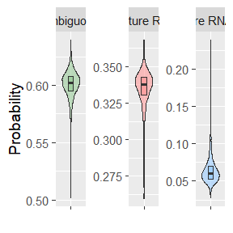

```r
library(ggplot2)
library(dplyr)
library(tidyr)

counts_data <- read.csv("D:/data/VeloRM_data/scDART-seq/origin/bam_read_counts.csv",
                       header = TRUE,  # Assumes first row contains column names
                       stringsAsFactors = FALSE)  # Prevents automatic conversion to factors

# View the first few rows

counts_data_sum <- apply(counts_data,1,function(x) sum(as.numeric(x[2:4])))
isoform_prop <- as.numeric(counts_data[,2])/counts_data_sum
spliced_prop <- as.numeric(counts_data[,3])/counts_data_sum
pre_prop <- as.numeric(counts_data[,4])/counts_data_sum

df <- data.frame(
  `mature RNA` = spliced_prop,
  `pre RNA` = pre_prop,
  `ambiguous` = isoform_prop,
  check.names = FALSE
)
df_long <- pivot_longer(df, cols = everything(),
                       names_to = "Type",
                       values_to = "Probability")

box_plot <- ggplot(df_long, aes(x = "", y = Probability, fill = Type)) +
    geom_violin(alpha = 0.6, width = 0.7) +
    geom_boxplot(width = 0.2, alpha = 0.8,
                 outlier.shape = NA,
                 coef = 0) +
    facet_wrap(~Type, scales = "free_y", ncol = 3) +
    labs(
        title = NULL,
        x = NULL,
        y = "Probability"
    ) +
    # Use theme_gray() which is the default ggplot2 theme
    theme_gray(base_size = 14)  +
    scale_fill_manual(
        values = c("mature RNA" = "#FF9999",
                   "pre RNA" = "#99CCFF",
                   "ambiguous" = "#99CC99"),
        breaks = c("mature RNA", "pre RNA", "ambiguous")
    )+
  theme(
    legend.position = "none"
  )

box_plot
```

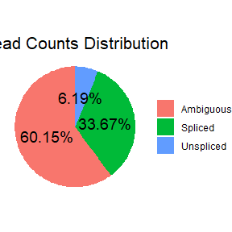

```r
# Prepare plot_data as before
plot_data <- data.frame(
  category = c("Spliced", "Unspliced", "Ambiguous"),
  proportion = c(sum(counts_data[,3]), sum(counts_data[,4]), sum(counts_data[,2]))
)

# Add a fraction/percentage column for labels
plot_data$percentage <- round(plot_data$proportion / sum(plot_data$proportion) * 100, 2)

# Create pie chart
pie_chart <- ggplot(plot_data, aes(x = "", y = proportion, fill = category)) +
  geom_bar(stat = "identity", width = 1) +    # stacked bar
  coord_polar(theta = "y") +                  # convert to pie chart
  geom_text(aes(label = paste0(percentage, "%")),
            position = position_stack(vjust = 0.5), size = 5) + # Add percentages inside slices
  labs(title = "Read Counts Distribution") +
  theme_void() +                              # Clean theme without axes
  theme(legend.title = element_blank(),       # Remove legend title
        plot.title = element_text(hjust = 0.5, size = 16))     # Center title

pie_chart
```

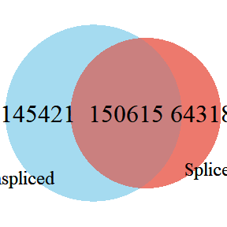

```r
# SigRMtest_res_spliced_overall <- readRDS("D:/data/VeloRM_data/scDART-seq/pre_process/SigRMtest_res_spliced_overall.rds")
# SigRMtest_res_spliced_overall_pvalue_median <- apply(SigRMtest_res_spliced_overall$`p value`,1,function(x) median(x,na.rm = TRUE))
SigRMtest_res_spliced_overall_pvalue_median <- readRDS("D:/data/VeloRM_data/scDART-seq/pre_process/SigRMtest_res_spliced_overall_pvalue_median.rds")
spliced_index <- which(SigRMtest_res_spliced_overall_pvalue_median<=0.05)
#
# SigRMtest_res_unspliced_overall <- readRDS("D:/data/VeloRM_data/scDART-seq/pre_process/SigRMtest_res_unspliced_overall.rds")
# SigRMtest_res_unspliced_overall_pvalue_median <- apply(SigRMtest_res_unspliced_overall$`p value`,1,function(x) median(x,na.rm = TRUE))
SigRMtest_res_unspliced_overall_pvalue_median <- readRDS("D:/data/VeloRM_data/scDART-seq/pre_process/SigRMtest_res_unspliced_overall_pvalue_median.rds")
unspliced_index <- which(SigRMtest_res_unspliced_overall_pvalue_median<=0.05)

spliced_index_l <- length(spliced_index)
unspliced_index_l <- length(unspliced_index)
intersect_l <- length(intersect(spliced_index,unspliced_index))


library(VennDiagram)
grid.newpage()
venn <-draw.pairwise.venn(
  area1 = spliced_index_l,
  area2 = unspliced_index_l,
  cross.area = intersect_l,
  category = c("Spliced", "Unspliced"),
  fill = c("#E74C3C","skyblue"),
  alpha = 0.5,
  lty = "blank",
  cex = 2,
  cat.cex = 1.5
)

grid.draw(venn)
```

### splicing jucntion distance

```r
library(GenomicRanges)
library(rtracklayer)
library(dplyr)
library(tidyr)

snp <- readRDS("D:/data/VeloRM_data/scDART-seq/pre_process/SNP_37199.rds")
snp_pos <- snp@ranges@start
snp_chr_length <- snp@seqnames@lengths
snp_chr_seq <- snp@seqnames@values
snp_chr <- as.character(rep(snp_chr_seq,snp_chr_length))
snp_strand <- snp@elementMetadata@listData[["transcript_strand"]]
snp_data <- as.data.frame(cbind(snp_chr,snp_pos,snp_strand))
snp_data$snp_pos <- as.numeric(snp_data$snp_pos)




# Read the GTF file from Ensembl
gtf_file <- "D:/data/VeloRM_data/scDART-seq/origin/gencode.v47.chr_patch_hapl_scaff.annotation.gtf"
gtf_data <- import(gtf_file)

# Filter for exons
exons <- gtf_data[gtf_data$type == "exon"]

# Convert to data frame
exons_df <- data.frame(
chr = as.character(seqnames(exons)),
start = start(exons),
end = end(exons),
strand = as.character(strand(exons)),
gene_id = mcols(exons)$gene_id,
transcript_id = mcols(exons)$transcript_id
)

# Sort exons by transcript and position
exons_df <- exons_df %>%
arrange(transcript_id, chr, start)

# Extract splicing junctions using intron boundaries
junctions <- exons_df %>%
group_by(transcript_id) %>%
arrange(if_else(strand == "+", start, -start)) %>%  # Sort based on strand
mutate(
  donor_site = end,                # End of the upstream exon
  acceptor_site = lead(start)      # Start of the downstream exon
) %>%
filter(!is.na(acceptor_site)) %>%   # Remove the last exon (no downstream exon)
ungroup() %>%
select(chr, donor_site, acceptor_site, gene_id, transcript_id, strand)


junctions_unique <- junctions %>%
 distinct(chr, donor_site, acceptor_site, .keep_all = TRUE)



junctions_long <- junctions_unique %>%
 pivot_longer(cols = c(donor_site, acceptor_site),
              names_to = "site_type",
              values_to = "site_position") %>%
 select(chr, site_position, site_type, gene_id, transcript_id, strand)



# Calculate distance from each SNP to the nearest junction (matching chr and strand)
snp_with_distance <- snp_data %>%
 rowwise() %>%
 mutate(
   nearest_junction_distance = min(
     abs(junctions_long$site_position[junctions_long$chr == snp_chr & junctions_long$strand == snp_strand] - snp_pos),
     na.rm = TRUE
   )
 )


# get normal chr
standard_chromosomes <- paste0("chr", c(1:22, "X", "Y"))

# get the exon with the normal chr
exons_filtered <- exons[seqnames(exons) %in% standard_chromosomes]



# calculate the distance
exon_lengths <- width(exons_filtered)

# calculate the prob
prob_weights <- exon_lengths / sum(exon_lengths)

# random sample
set.seed(123)


#random_distances_list <- list()

#for (i in 1:10){
 selected_exons <- sample(seq_along(exons_filtered), size = 37199, replace = TRUE, prob = prob_weights)
 # choose the site in the select the exons
 random_positions <- start(exons[selected_exons]) +
   floor(runif(37199, min = 0, max = exon_lengths[selected_exons]))

 # create the data frame
 random_sites <- data.frame(
   chr = as.character(seqnames(exons[selected_exons])),
   position = random_positions,
   strand = as.character(strand(exons[selected_exons]))
 )


 # Calculate distance from each SNP to the nearest junction (matching chr and strand)
 random_sites_with_distance <- random_sites %>%
   rowwise() %>%
   mutate(
     nearest_junction_distance = min(
       abs(junctions_long$site_position[junctions_long$chr == chr & junctions_long$strand == strand] - position),
       na.rm = TRUE
     )
   )
 random_distances_list  <- random_sites_with_distance$nearest_junction_distance
#}



random_distances_df <- data.frame(
 distance = random_distances_list,
 group = "Random"
)

# merge the data frame
real_distances_df <- data.frame(
 distance = snp_with_distance$nearest_junction_distance,
 group = "Real"
)


all_distances_df <- bind_rows(random_distances_df, real_distances_df)
group_order <- c("Real","Random")
all_distances_df$group <- factor(all_distances_df$group, levels = group_order)
library(ggplot2)
#  Boxplot
plot <- ggplot(all_distances_df, aes(x = group, y = log10(distance+1), fill = group)) +
 geom_violin(trim = FALSE, alpha = 0.5) +
 geom_boxplot(width = 0.1, outlier.shape = NA)+
 scale_fill_manual(values = c("red",rep("lightblue", 10))) +
 labs(title = NULL,
      x = NULL,
      y = "log10(Distance (bp)+1)") +
 theme_grey() +
 theme(plot.title = element_text(hjust = 0.5),
       legend.position = "none")+coord_cartesian(ylim = c(0,5))


saveRDS(all_distances_df,"D:/data/VeloRM_data/scDART-seq/results/splicing_junction_analysis/all_distances_df.rds")
```

#### vis

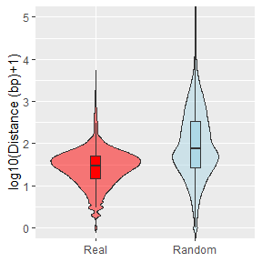

```r
 all_distances_df <- readRDS("D:/data/VeloRM_data/scDART-seq/results/splicing_junction_analysis/all_distances_df.rds")

library(ggplot2)
#  Boxplot
plot <- ggplot(all_distances_df, aes(x = group, y = log10(distance+1), fill = group)) +
 geom_violin(trim = FALSE, alpha = 0.5) +
 geom_boxplot(width = 0.1, outlier.shape = NA)+
 scale_fill_manual(values = c("red",rep("lightblue", 10))) +
 labs(title = NULL,
      x = NULL,
      y = "log10(Distance (bp)+1)") +
 theme_grey() +
 theme(plot.title = element_text(hjust = 0.5),
       legend.position = "none")+coord_cartesian(ylim = c(0,5))
plot
```

### read the DESeq2 results

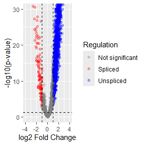

```r
library(ggplot2)
library(dplyr)
library(tidyr)

res_DESeq2 <- readRDS("D:/data/VeloRM_data/scDART-seq/pre_process/res_DESeq2.rds")


log2FC <-res_DESeq2@listData[["log2FoldChange"]]
pvals <- res_DESeq2@listData[["pvalue"]]

plot_data <- data.frame(log2FC = log2FC,
                       pvalue = pvals,
                       neg_log10_p = -log10(pvals))
set.seed(42)
plot_data_5000_sample <- plot_data[sample(1:37199,5000),]

volcano_plot_DESeq2 <- ggplot(plot_data_5000_sample, aes(x = log2FC, y = neg_log10_p)) +
  # Add light gray background for -1 < log2FC < 1 (non-significant FC region)
  annotate("rect", xmin = -1, xmax = 1, ymin = 0, ymax = 30,
           fill = "gray90", alpha = 0.3) +

  # Color points based on significance and log2FC:
  # - Red: log2FC > 1 & p < 0.05 (significantly up-regulated)
  # - Blue: log2FC < -1 & p < 0.05 (significantly down-regulated)
  # - Gray: Not significant or |log2FC| ≤ 1
  geom_point(aes(color = case_when(
    log2FC > 1 & pvalue < 0.05 ~ "Unspliced",
    log2FC < -1 & pvalue < 0.05 ~ "Spliced",
    TRUE ~ "Not significant"
  )), alpha = 0.3) +

  # Manual color scale (red, blue, gray)
  scale_color_manual(
    values = c(
      "Spliced" = "red",
      "Unspliced" = "blue",
      "Not significant" = "gray50"
    ),
    name = "Regulation"  # Legend title
  ) +

  # Add dashed lines for thresholds:
  # - Vertical: log2FC = ±1
  # - Horizontal: p-value = 0.05 (-log10(0.05) ≈ 1.3)
  geom_vline(xintercept = c(-1, 1), linetype = "dashed", color = "black") +
  geom_hline(yintercept = -log10(0.05), linetype = "dashed", color = "black") +

  # Axis labels and theme
  labs(
    x = "log2 Fold Change",
    y = "-log10(p-value)",
    title = NULL
  ) +
   theme_grey() +
   # Set axis limits (zoomed-in view)
   coord_cartesian(ylim = c(0, 30),xlim = c(-4, 4))
volcano_plot_DESeq2
```

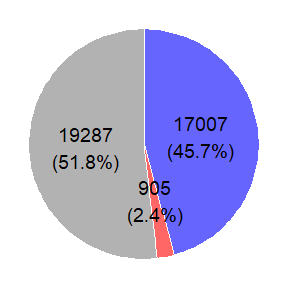

```r
n_unspliced <- length(which(log2FC >= 1 & pvals <= 0.05))
n_spliced <- length(which(log2FC <= -1 & pvals <= 0.05))
n_nonsig <- sum(pvals > 0.05 | (log2FC > -1 & log2FC < 1))

total <- n_unspliced + n_spliced + n_nonsig
Percentage <- round(c(n_unspliced, n_spliced, n_nonsig) / total * 100, 1)

df <- data.frame(
  Category = c("Unspliced", "Spliced", "Insignificant"),
  Count = c(n_unspliced, n_spliced, n_nonsig)
)



pie_chart_DESeq2 <- ggplot(df, aes(x = "", y = Count, fill = Category)) +
  geom_bar(stat = "identity", width = 1, color = "white",alpha=0.6) +
  coord_polar("y", start = 0) +
  geom_text(aes(label = paste0(Count, "\n(", Percentage, "%)")),
            position = position_stack(vjust = 0.5), size = 5) +
  scale_fill_manual(values = c("Unspliced" = "blue", "Spliced" = "red","Insignificant"="gray50")) +
  labs(
    title = NULL,
    x = NULL,
    y = NULL
  ) +
  theme_void() +
  theme(
    legend.position = "none"
  )

pie_chart_DESeq2
```

### meth density

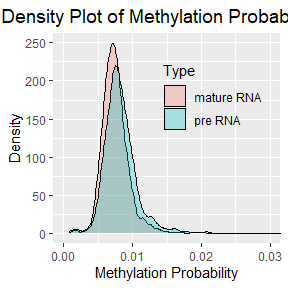

```r
# Load input data
test.list <- readRDS("D:/data/VeloRM_data/scDART-seq/pre_process/test.list.rds")

# Extract different parts of the data
spliced.meth.test <- test.list[[1]]  # Methylated spliced data
spliced.unmeth.test <- test.list[[2]]  # Unmethylated spliced data
unspliced.meth.test <- test.list[[3]]  # Methylated unspliced data
unspliced.unmeth.test <- test.list[[4]]  # Unmethylated unspliced data
isoform.meth.test <- test.list[[5]]  # Methylated isoform data
isoform.unmeth.test <- test.list[[6]]  # Unmethylated isoform data





spliced.meth.sum.cell <- apply(spliced.meth.test,2,sum)#,apply(spliced.meth.control,2,sum))
spliced.unmeth.sum.cell <- apply(spliced.unmeth.test,2,sum)#,apply(spliced.unmeth.control,2,sum))
unspliced.meth.sum.cell <- apply(unspliced.meth.test,2,sum)#,apply(unspliced.meth.control,2,sum))
unspliced.unmeth.sum.cell <- apply(unspliced.unmeth.test,2,sum)#,apply(unspliced.unmeth.control,2,sum))
isoform.meth.sum.cell <- apply(isoform.meth.test,2,sum)#,apply(unspliced.meth.control,2,sum))
isoform.unmeth.sum.cell <- apply(isoform.unmeth.test,2,sum)#,apply(unspliced.unmeth.control,2,sum))

spliced.sum.cell <- spliced.meth.sum.cell + spliced.unmeth.sum.cell
unspliced.sum.cell <- unspliced.meth.sum.cell + unspliced.unmeth.sum.cell
isoform.sum.cell <- isoform.meth.sum.cell + isoform.unmeth.sum.cell

spliced.prob.cell <- spliced.sum.cell/(spliced.sum.cell+unspliced.sum.cell+isoform.sum.cell)
unspliced.prob.cell <- unspliced.sum.cell/(spliced.sum.cell+unspliced.sum.cell+isoform.sum.cell)
isoform.prob.cell <- isoform.sum.cell/(spliced.sum.cell+unspliced.sum.cell+isoform.sum.cell)


spliced.cell.prob <- spliced.meth.sum.cell/(spliced.unmeth.sum.cell+spliced.meth.sum.cell)
unspliced.cell.prob <- unspliced.meth.sum.cell/(unspliced.unmeth.sum.cell+unspliced.meth.sum.cell)

df <- data.frame(
  Probability = c(spliced.cell.prob, unspliced.cell.prob),
  Type = rep(c("mature RNA", "pre RNA"),
             c(length(spliced.cell.prob), length(unspliced.cell.prob)))
)

# Create the density plot
ggplot(df, aes(x = Probability, fill = Type)) +
  geom_density(alpha = 0.3) +
  labs(title = "Density Plot of Methylation Probabilities",
       x = "Methylation Probability",
       y = "Density") +
  theme_grey() +
  coord_cartesian(xlim=c(0,0.03))+
  theme(
    plot.title = element_text(hjust = 0.5, size = 14),
    legend.position = c(0.7, 0.7),
    legend.background = element_blank())
```

### Regulatory mechanisms

```r
library(TxDb.Hsapiens.UCSC.hg38.knownGene)
library(MetaTX)
library(ggplot2)
library(dplyr)


SigRMtest_res_spliced <- readRDS("D:/data/VeloRM_data/scDART-seq/pre_process/SigRMtest_res_spliced.rds")
SigRMtest_res_unspliced <- readRDS("D:/data/VeloRM_data/scDART-seq/pre_process/SigRMtest_res_unspliced.rds")

SigRMtest_res_spliced_pvalue_median <- apply(SigRMtest_res_spliced$`p value`,1,function(x) median(x,na.rm = TRUE))
SigRMtest_res_unspliced_pvalue_median <- apply(SigRMtest_res_unspliced$`p value`,1,function(x) median(x,na.rm = TRUE))

index_pre_siginificant_spliced_insiginificant <- which(SigRMtest_res_unspliced_pvalue_median<=0.05)

index_spliced_siginificant_pre_insiginificant <- which(SigRMtest_res_spliced_pvalue_median<=0.05)
```

#### Finding sites where methylation levels are high in pre-mRNA but low in spliced mRNA, as well as sites where methylation levels are high in spliced mRNA but low in pre-mRNA.

```r
res_preprocess <- readRDS("D:/data/VeloRM_data/scDART-seq/pre_process/res_preprocess.rds")
spliced_methylation_OR_value_meta <- res_preprocess$spliced_methylation_OR_value_meta
unspliced_methylation_OR_value_meta <- res_preprocess$unspliced_methylation_OR_value_meta


index_pre_high_spliced_low <- which(unspliced_methylation_OR_value_meta-spliced_methylation_OR_value_meta>=1)
index_spliced_high_pre_low <- which(spliced_methylation_OR_value_meta-unspliced_methylation_OR_value_meta>=1)
```

#### metaTX plot

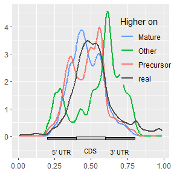

```r
intersect_pre_dominate <- intersect(index_pre_high_spliced_low,which(SigRMtest_res_unspliced_pvalue_median<=0.05))

intersect_spliced_dominate <- intersect(index_spliced_high_pre_low,which(SigRMtest_res_spliced_pvalue_median<=0.05))

intersect_pre_dominate <-intersect_pre_dominate[order(SigRMtest_res_unspliced_pvalue_median[intersect_pre_dominate])[1:500]]

intersect_spliced_dominate <-intersect_spliced_dominate[order(SigRMtest_res_spliced_pvalue_median[intersect_spliced_dominate])[1:500]]

# SigRMtest_res_overall <- readRDS("D:/data/VeloRM_data/scDART-seq/pre_process/SigRMtest_res_overall.rds")
# SigRMtest_res_overall_pvalue_median <- apply(SigRMtest_res_overall$`p value`,1,function(x) median(x,na.rm = TRUE))
SigRMtest_res_overall_pvalue_median <-readRDS("D:/data/VeloRM_data/scDART-seq/pre_process/SigRMtest_res_overall_pvalue_median.rds")
index_not_dominate <- order(SigRMtest_res_overall_pvalue_median)[1:500]

# metaTX


SNP_37199 <- readRDS("D:/data/VeloRM_data/scDART-seq/pre_process/SNP_37199.rds")
SNP_all <- readRDS("D:/data/VeloRM_data/scDART-seq/origin/SNP_all.rds")
index_error <- readRDS("D:/data/VeloRM_data/scDART-seq/pre_process/index_error.rds")
SNP_450974 <-SNP_all[index_error]
txdb <- TxDb.Hsapiens.UCSC.hg38.knownGene

SNP_intersect_pre_dominate <- SNP_37199[intersect_pre_dominate]
SNP_intersect_spliced_dominate <- SNP_37199[intersect_spliced_dominate]
SNP_intersect_not_dominate <- SNP_450974[index_not_dominate]
SNP_background <- SNP_37199

SNP_to_exclude <- c(SNP_intersect_pre_dominate, SNP_intersect_spliced_dominate)

library(GenomicRanges)
hits <- findOverlaps(SNP_intersect_not_dominate, SNP_to_exclude)

if(length(hits)!=0){
  SNP_intersect_not_dominate<- SNP_intersect_not_dominate[-queryHits(hits)]
}


# minus transcript strand +1, plus transcript strand -1
SNP_intersect_pre_dominate_adjusted <- SNP_intersect_pre_dominate
pos_strand <- mcols(SNP_intersect_pre_dominate)$transcript_strand == "+"
neg_strand <- mcols(SNP_intersect_pre_dominate)$transcript_strand == "-"

SNP_intersect_pre_dominate_adjusted[pos_strand]@ranges@start <-
   as.integer(SNP_intersect_pre_dominate_adjusted[pos_strand]@ranges@start - 1)
SNP_intersect_pre_dominate_adjusted[neg_strand]@ranges@start <-
   as.integer(SNP_intersect_pre_dominate_adjusted[neg_strand]@ranges@start + 1)


SNP_intersect_spliced_dominate_adjusted <- SNP_intersect_spliced_dominate
pos_strand <- mcols(SNP_intersect_spliced_dominate)$transcript_strand == "+"
neg_strand <- mcols(SNP_intersect_spliced_dominate)$transcript_strand == "-"

SNP_intersect_spliced_dominate_adjusted[pos_strand]@ranges@start <-
   as.integer(SNP_intersect_spliced_dominate_adjusted[pos_strand]@ranges@start - 1)
SNP_intersect_spliced_dominate_adjusted[neg_strand]@ranges@start <-
   as.integer(SNP_intersect_spliced_dominate_adjusted[neg_strand]@ranges@start + 1)




SNP_intersect_not_dominate_adjusted <- SNP_intersect_not_dominate
pos_strand <- mcols(SNP_intersect_not_dominate)$transcript_strand == "+"
neg_strand <- mcols(SNP_intersect_not_dominate)$transcript_strand == "-"

SNP_intersect_not_dominate_adjusted[pos_strand]@ranges@start <-
   as.integer(SNP_intersect_not_dominate_adjusted[pos_strand]@ranges@start - 1)
SNP_intersect_not_dominate_adjusted[neg_strand]@ranges@start <-
   as.integer(SNP_intersect_not_dominate_adjusted[neg_strand]@ranges@start + 1)


SNP_background_adjusted <- SNP_background
pos_strand <- mcols(SNP_background)$transcript_strand == "+"
neg_strand <- mcols(SNP_background)$transcript_strand == "-"

SNP_background_adjusted[pos_strand]@ranges@start <-
   as.integer(SNP_background_adjusted[pos_strand]@ranges@start - 1)
SNP_background_adjusted[neg_strand]@ranges@start <-
   as.integer(SNP_background_adjusted[neg_strand]@ranges@start + 1)

remap_results_pre_dominate <- remapCoord(features = SNP_intersect_pre_dominate_adjusted, txdb = txdb)
remap_results_spliced_dominate <- remapCoord(features = SNP_intersect_spliced_dominate_adjusted, txdb = txdb)
remap_results_not_dominate <- remapCoord(features = SNP_intersect_not_dominate_adjusted, txdb = txdb)
remap_results_background <- remapCoord(features = SNP_background_adjusted, txdb = txdb)

# Step 2: Create plots for each subset
plot_pre_dominate <- directPlot(remap_results_pre_dominate)
plot_spliced_dominate <- directPlot(remap_results_spliced_dominate)
plot_not_dominate <- directPlot(remap_results_not_dominate)
plot_background <- directPlot(remap_results_background)

data_a <- ggplot_build(plot_pre_dominate)$data[[1]] %>% mutate(Group = "Precursor")
data_b <- ggplot_build(plot_spliced_dominate)$data[[1]] %>% mutate(Group = "Mature")
data_c <- ggplot_build(plot_not_dominate)$data[[1]] %>% mutate(Group = "Other")
data_d <- ggplot_build(plot_background)$data[[1]] %>% mutate(Group = "real")

# Combine all datasets
combined_data <- bind_rows(data_a, data_b, data_c,data_d)#, data_intersect)

region_rects <- data.frame(
    xmin = c(0.2, 0.4, 0.6),  # Start positions of each region
    xmax = c(0.4, 0.6, 0.8),  # End positions of each region
    ymin = min(combined_data$y, na.rm = TRUE) - 0.1,  # Adjust below data range
    ymax = min(combined_data$y, na.rm = TRUE) - 0.05, # Slightly higher to make room
    Region = c("5' UTR", "CDS", "3' UTR")
)

# Calculate the height of 5' UTR and 3' UTR regions
utr_height <- region_rects$ymax[region_rects$Region == "5' UTR"] - region_rects$ymin[region_rects$Region == "5' UTR"]

# Increase the height of CDS region by 20% (can be adjusted as needed)
cds_height <- utr_height * 2 # Increase height by 30%

# Set ymin and ymax for CDS so that it is centered with respect to 5' UTR and 3' UTR
region_rects$ymin[region_rects$Region == "CDS"] <- region_rects$ymin[region_rects$Region == "CDS"] - 0.5*utr_height  # Decrease ymin for CDS
region_rects$ymax[region_rects$Region == "CDS"] <- region_rects$ymin[region_rects$Region == "CDS"] + cds_height  # Increase ymax for CDS


compare_metaTX_plot <-ggplot(combined_data, aes(x = x, y = y, color = Group))+
  geom_line(size=1)+
    # Add region highlights using geom_rect, with consistent positioning across all facets
    geom_rect(data = region_rects, aes(xmin = xmin, xmax = xmax, ymin = ymin, ymax = ymax, fill = Region),
              inherit.aes = FALSE, color = "black", alpha = 0.4,
              linewidth = 0.5) +  # Default linewidth for all regions
    # Set fill for CDS region to grey (lighter than black)
    geom_rect(data = subset(region_rects, Region == "CDS"), aes(xmin = xmin, xmax = xmax, ymin = ymin, ymax = ymax),
              inherit.aes = FALSE, fill = "grey", color = "black", alpha = 0.4, linewidth = 0.5) +  # Grey fill for CDS
    # Adjust 5' UTR and 3' UTR fills to a very dark grey, closer to black
    geom_rect(data = subset(region_rects, Region != "CDS"), aes(xmin = xmin, xmax = xmax, ymin = ymin, ymax = ymax,
                                                                fill = factor(Region, levels = c("5' UTR", "3' UTR"))),
              inherit.aes = FALSE, color = "black", alpha = 0.3, linewidth = 0.5) +
    scale_fill_manual(values = c("5' UTR" = grey(0.15),  # Very dark grey for 5' UTR, closer to black
                                "CDS" = "grey",           # Grey for CDS
                                "3' UTR" = grey(0.15))) +  # Very dark grey for 3' UTR
    # Adjust y position for the text annotations to place them above the rectangles
    geom_text(data = region_rects, aes(x = (xmin + xmax) / 2, y = ymax - 0.5, label = Region),
              inherit.aes = FALSE, color = "black", size = 3, hjust = 0.5) +
    # Remove Region fill legend
    guides(fill = "none")+scale_color_manual(values = c(
  "Other" = "#00ba38",
  "Mature" = "#619cff",
  "Precursor" = "#F8766d",
  "real" = "#4D4D4D"
),name = "Higher on")+theme_grey()+
  theme(
    legend.position = c(0.85, 0.7),
    legend.background = element_blank()  )+xlab(NULL)+ylab(NULL)
compare_metaTX_plot
```

#### find the index of site only detect methylated reads in spliced or pre mRNA

```r
index_meth_only_detect_pre <-  which(res_preprocess[["vg.test"]] %in% res_preprocess[["index"]][["methylation only occurs at unspliced RNA"]])

index_meth_only_detect_spliced <-  which(res_preprocess[["vg.test"]] %in%res_preprocess[["index"]][["methylation only occurs at spliced RNA"]])

intersect_pre_dominate <- intersect(index_pre_high_spliced_low,which(SigRMtest_res_unspliced_pvalue_median<=0.05))

intersect_spliced_dominate <- intersect(index_spliced_high_pre_low,which(SigRMtest_res_spliced_pvalue_median<=0.05))


# only detect at spliced
index_meth_only_detect_spliced_int <-  intersect(index_meth_only_detect_spliced,intersect_spliced_dominate)
SNP_37199[index_meth_only_detect_spliced_int]
```

```
#> GRanges object with 32 ranges and 5 metadata columns:
#>        seqnames    ranges strand |         ref         alt
#>           <Rle> <IRanges>  <Rle> | <character> <character>
#>    [1]     chr1  19242389      + |           G           A
#>    [2]     chr1 235494795      + |           G           A
#>    [3]     chr4  77030878      + |           C           T
#>    [4]     chr3  50330695      + |           G           A
#>    [5]     chr1 110045024      + |           C           T
#>    ...      ...       ...    ... .         ...         ...
#>   [28]    chr15  74627643      + |           C           T
#>   [29]     chr7 151075395      + |           C           T
#>   [30]     chr1  92304000      + |           C           T
#>   [31]    chr19   7642102      + |           C           T
#>   [32]     chr5  32379137      + |           G           A
#>        transcript_overlapped transcript_strand         seq
#>                  <character>       <character> <character>
#>    [1]     ENST00000477853.6                 -         GGT
#>    [2]     ENST00000366600.8                 -         AGT
#>    [3]     ENST00000502584.5                 +         ACT
#>    [4]     ENST00000327761.7                 -         AGT
#>    [5]     ENST00000369796.5                 +         ACA
#>    ...                   ...               ...         ...
#>   [28]     ENST00000345005.8                 +         ACT
#>   [29]     ENST00000485713.5                 +         ACT
#>   [30]     ENST00000610020.2                 +         ACT
#>   [31]     ENST00000598664.5                 +         ACT
#>   [32]    ENST00000265069.13                 -         AGT
#>   -------
#>   seqinfo: 24 sequences from an unspecified genome; no seqlengths
```

```r
library(biomaRt)

# Ensembl
ensembl <- useEnsembl(biomart = "genes", dataset = "hsapiens_gene_ensembl")

# ENST
transcript_ids <- SNP_37199[index_meth_only_detect_spliced_int]$transcript_overlapped

# clean
transcript_ids_clean <- gsub("\\..*", "", transcript_ids)

# find
transcript_info <- getBM(
  attributes = c("ensembl_transcript_id", "ensembl_gene_id", "external_gene_name",
                 "chromosome_name", "start_position", "end_position", "strand"),
  filters = "ensembl_transcript_id",
  values = transcript_ids_clean,
  mart = ensembl
)

idx <- match(transcript_ids_clean, transcript_info$ensembl_transcript_id)
transcript_info_ordered <- transcript_info[idx, ]
transcript_info_ordered <-transcript_info_ordered [,c(4,3,7)]
transcript_info_ordered$position <- SNP_37199[index_meth_only_detect_spliced_int]@ranges@start
transcript_info_ordered$position <- transcript_info_ordered$position-transcript_info_ordered$strand

transcript_info_ordered$SigRM_matrue_RNA <-
SigRMtest_res_spliced_pvalue_median[index_meth_only_detect_spliced_int]

transcript_info_ordered$SigRM_precursor_RNA <-
SigRMtest_res_unspliced_pvalue_median[index_meth_only_detect_spliced_int]

transcript_info_ordered$meta_OR <-
spliced_methylation_OR_value_meta[index_meth_only_detect_spliced_int]-unspliced_methylation_OR_value_meta[index_meth_only_detect_spliced_int]

transcript_info_ordered_spliced <-transcript_info_ordered



# only detect at pre
index_meth_only_detect_pre_int <- intersect(index_meth_only_detect_pre,intersect_pre_dominate)
SNP_37199[index_meth_only_detect_pre_int]
```

```
#> GRanges object with 21 ranges and 5 metadata columns:
#>        seqnames    ranges strand |         ref         alt
#>           <Rle> <IRanges>  <Rle> | <character> <character>
#>    [1]    chr22  38075006      + |           C           T
#>    [2]     chr3 119523753      + |           C           T
#>    [3]     chr3  97967309      + |           G           A
#>    [4]     chr7    842087      + |           C           T
#>    [5]     chr1  36093244      + |           C           T
#>    ...      ...       ...    ... .         ...         ...
#>   [17]     chr6  32974619      + |           C           T
#>   [18]     chr1 202946465      + |           G           A
#>   [19]    chr15  41365456      + |           C           T
#>   [20]    chr16  67616758      + |           C           T
#>   [21]    chr17  21028549      + |           G           A
#>        transcript_overlapped transcript_strand         seq
#>                  <character>       <character> <character>
#>    [1]     ENST00000404072.7                 +         ACC
#>    [2]     ENST00000493694.1                 +         ACT
#>    [3]     ENST00000394198.7                 -         AGT
#>    [4]     ENST00000427969.5                 +         ACG
#>    [5]     ENST00000373178.5                 +         ACC
#>    ...                   ...               ...         ...
#>   [17]     ENST00000374825.9                 +         ACC
#>   [18]    ENST00000340990.10                 -         AGT
#>   [19]     ENST00000668616.1                 +         ACT
#>   [20]     ENST00000646076.1                 +         ACA
#>   [21]     ENST00000261497.9                 -         TGT
#>   -------
#>   seqinfo: 24 sequences from an unspecified genome; no seqlengths
```

```r
library(biomaRt)

# Ensembl
ensembl <- useEnsembl(biomart = "genes", dataset = "hsapiens_gene_ensembl")

# ENST
transcript_ids <- SNP_37199[index_meth_only_detect_pre_int]$transcript_overlapped

# clean
transcript_ids_clean <- gsub("\\..*", "", transcript_ids)

# find
transcript_info <- getBM(
  attributes = c("ensembl_transcript_id", "ensembl_gene_id", "external_gene_name",
                 "chromosome_name", "start_position", "end_position", "strand"),
  filters = "ensembl_transcript_id",
  values = transcript_ids_clean,
  mart = ensembl
)

idx <- match(transcript_ids_clean, transcript_info$ensembl_transcript_id)
transcript_info_ordered <- transcript_info[idx, ]
transcript_info_ordered <-transcript_info_ordered [,c(4,3,7)]
transcript_info_ordered$position <- SNP_37199[index_meth_only_detect_pre_int]@ranges@start
transcript_info_ordered$position <- transcript_info_ordered$position-transcript_info_ordered$strand

transcript_info_ordered$SigRM_matrue_RNA <-
SigRMtest_res_spliced_pvalue_median[index_meth_only_detect_pre_int]

transcript_info_ordered$SigRM_precursor_RNA <-
SigRMtest_res_unspliced_pvalue_median[index_meth_only_detect_pre_int]

transcript_info_ordered$meta_OR <-
unspliced_methylation_OR_value_meta[index_meth_only_detect_pre_int]-spliced_methylation_OR_value_meta[index_meth_only_detect_pre_int]

transcript_info_ordered_pre <-transcript_info_ordered
```

### cell cycle trajectory using m6A velocity

#### find the 9 marker gens sites in 37199

```r
library(ggplot2)
library(svglite)
library(VeloRM)
## step1 : choose gene
g1_s_genes <- c("MCM6", "PCNA", "SLBP")
s_genes <- c( "RRM2", "DTL","MCM5")
g2_m_genes <- c("TOP2A",  "CCNB1", "AURKA" )






library(org.Hs.eg.db)
library(clusterProfiler)
library(stringi)



g1_s_genes_ENSG <- bitr(g1_s_genes, fromType="SYMBOL", toType="ENSEMBL", OrgDb="org.Hs.eg.db")
s_genes_ENSG <- bitr(s_genes, fromType="SYMBOL", toType="ENSEMBL", OrgDb="org.Hs.eg.db")
g2_m_genes_ENSG <-bitr(g2_m_genes, fromType="SYMBOL", toType="ENSEMBL", OrgDb="org.Hs.eg.db")


## step3 : select the tpm data
select_gene <- c(g1_s_genes_ENSG$ENSEMBL,s_genes_ENSG$ENSEMBL,g2_m_genes_ENSG$ENSEMBL)


library(biomaRt)

# Connect to Ensembl
ensembl <- useEnsembl(biomart = "genes", dataset = "hsapiens_gene_ensembl")




# Query positional information with strand
pos_info <- getBM(attributes = c("ensembl_gene_id",
                                 "chromosome_name",
                                 "start_position",
                                 "end_position",
                                 "strand"),
                  filters = "ensembl_gene_id",
                  values = select_gene,
                  mart = ensembl)

# Convert strand information from numeric to "+" or "-"
pos_info$strand <- ifelse(pos_info$strand == 1, "+", "-")
pos_info <- pos_info[match(select_gene, pos_info$ensembl_gene_id), ]

# Print the ordered positional information
print(pos_info)


library(ggplot2)


SNP_37199 <- readRDS("D:/data/VeloRM_data/scDART-seq/pre_process/SNP_37199.rds")

# find the 9 gens site

# the sites position
testSNP_all_position <- SNP_37199@ranges@start

# match the site to the gene
index_list <- list()
for ( i in 1:length(select_gene)){
  index_list[[i]] <-which(testSNP_all_position%in%(pos_info$start_position[i]:pos_info$end_position[i]))
  if(length(index_list[[i]])==0){

  }else{
    names(index_list[[i]]) <- paste0("gene_",i,"_",1:length(index_list[[i]]))
  }

}



# all index of sites
index_site <- unlist(index_list)
site_length <- unlist(lapply(index_list, length))


chr_info <- rep(SNP_37199@seqnames@values,SNP_37199@seqnames@lengths)
chr_info_get <- chr_info[index_site]
chr_info_target <- factor(rep(paste0("chr",pos_info$chromosome_name),site_length),levels = levels(chr_info_get))

index_correct <- which(chr_info_get ==chr_info_target)
site_length_correct <- list()
start <- 1
end <- site_length[1]
for (i in 1:8){
  site_length_correct[[i]] <- length(which(index_correct%in%c(start:end)))
  start <- start+site_length[i]
  end <- end + site_length[i+1]
}
site_length_correct[[9]] <- length(which(index_correct%in%c(start:end)))
site_index_correct <- index_site [index_correct]

index_site <- site_index_correct
index_site_SNP <- SNP_37199[index_site]
site_length <- unlist(site_length_correct)
names(site_length) <- c(g1_s_genes,s_genes,g2_m_genes )
# saveRDS(index_site,"D:/data/VeloRM_data/scDART-seq/results/cell_cycle_sites/index_site.rds")
# saveRDS(index_site_SNP,"D:/data/VeloRM_data/scDART-seq/results/cell_cycle_sites/index_site_SNP.rds")
# saveRDS(site_length,"D:/data/VeloRM_data/scDART-seq/results/cell_cycle_sites/site_length.rds")
```

#### run the m6A velocity and expression velocity

```r
res_preprocess <- readRDS("/gpfs/work/bio/haozhewang17/data/VeloRM_data/pre_process/res_preprocess.rds")
# the input data
test.list <- readRDS("/gpfs/work/bio/haozhewang17/data/VeloRM_data/pre_process/test.list.rds")
control.list <- readRDS("/gpfs/work/bio/haozhewang17/data/VeloRM_data/pre_process/control.list.rds")


spliced.meth.test <- test.list[[1]]
spliced.unmeth.test <- test.list[[2]]
unspliced.meth.test <- test.list[[3]]
unspliced.unmeth.test <- test.list[[4]]

kCells = 1; deltaT = 0.01; kSites = 1
library(VeloRM)
# calculate the emat_size and nmat_size

emat_size <- colSums(spliced.meth.test + spliced.unmeth.test)
nmat_size <- colSums(unspliced.meth.test + unspliced.unmeth.test)

res <- methylation.site.relative.velocity.estimates(res_preprocess$test, res_preprocess$control,
                                                    kCells = kCells, deltaT = deltaT, kSites = kSites,
                                                    fit.quantile = 0.05, n.cores = 1, emat.size = emat_size,
                                                    nmat.size = nmat_size)

# saveRDS(res, "/gpfs/work/bio/haozhewang17/data/VeloRM_data/results/res_m6A_velocity.rds")


## run the velocity


# the input data
test.list <- readRDS("/gpfs/work/bio/haozhewang17/data/VeloRM_data/pre_process/test.list.rds")
control.list <- readRDS("/gpfs/work/bio/haozhewang17/data/VeloRM_data/pre_process/control.list.rds")


spliced.meth.test <- test.list[[1]]
spliced.unmeth.test <- test.list[[2]]
unspliced.meth.test <- test.list[[3]]
unspliced.unmeth.test <- test.list[[4]]

kCells = 1; deltaT = 0.01; kSites = 1
library(VeloRM)
# calculate the emat_size and nmat_size

emat_size <- colSums(spliced.meth.test + spliced.unmeth.test)
nmat_size <- colSums(unspliced.meth.test + unspliced.unmeth.test)

res <- site.relative.velocity.estimates(emat = spliced.meth.test+spliced.unmeth.test,
                                        nmat = unspliced.meth.test+unspliced.unmeth.test,
                                                    kCells = kCells, deltaT = deltaT, kSites = kSites,
                                                    fit.quantile = 0.05, n.cores = 1, emat.size = emat_size,
                                                    nmat.size = nmat_size)

# saveRDS(res, "/gpfs/work/bio/haozhewang17/data/VeloRM_data/results/res_aboundance_velocity.rds")
```

#### OR embedding

filter the sites

```r
library(ggplot2)

res <- readRDS("D:/data/VeloRM_data/scDART-seq/results/res_m6A_velocity.rds")
## PCA

label_SigRM <- readRDS("D:/data/VeloRM_data/scDART-seq/origin/label_SigRM.rds")

label_phase <- rep(NA,1209)
names(label_phase) <- colnames(res[[1]][["conv.nmat.norm"]])

label_phase[names(label_SigRM)] <- label_SigRM
index <- which(label_phase=="G1"|label_phase=="G2/M"|label_phase=="S")

# OR
index_site <- readRDS("D:/data/VeloRM_data/scDART-seq/results/cell_cycle_sites/index_site.rds")
site_length <- readRDS("D:/data/VeloRM_data/scDART-seq/results/cell_cycle_sites/site_length.rds")
res_preprocess <- readRDS("D:/data/VeloRM_data/scDART-seq/pre_process/res_preprocess.rds")
index_site_name <- res_preprocess[["vg.test"]][index_site]

index_site_name_int <- intersect(index_site_name,rownames(res[[3]][["current"]]$OR))

spliced_methylation_OR_value_meta_index <- res_preprocess[["spliced_methylation_OR_value_meta"]][index_site_name_int]
unspliced_methylation_OR_value_meta_index <-res_preprocess[["unspliced_methylation_OR_value_meta"]][index_site_name_int]


index_site_name_int_intersect <-index_site_name_int[which(spliced_methylation_OR_value_meta_index>=1&
                               unspliced_methylation_OR_value_meta_index>=1)]


index_site_name_int_intersect_gene_info <- rep(names(site_length),site_length)[which(index_site_name%in%index_site_name_int_intersect)]

# saveRDS(index_site_name_int_intersect,"D:/data/VeloRM_data/scDART-seq/results/cell_cycle_sites/index_site_name_int_intersect.rds")
```

##### OR embedding tsne

```r
rm(list = ls())
gc()
```

```
#>            used  (Mb) gc trigger    (Mb)   max used    (Mb)
#> Ncells 10256336 547.8   19011752  1015.4   19011752  1015.4
#> Vcells 19201731 146.5 2322481781 17719.2 2417746785 18446.0
```

```r
res <- readRDS("D:/data/VeloRM_data/scDART-seq/results/res_m6A_velocity.rds")
index_site_name_int_intersect <- readRDS("D:/data/VeloRM_data/scDART-seq/results/cell_cycle_sites/index_site_name_int_intersect.rds")
label_SigRM <- readRDS("D:/data/VeloRM_data/scDART-seq/origin/label_SigRM.rds")

label_phase <- rep(NA,1209)
names(label_phase) <- colnames(res[[1]][["conv.nmat.norm"]])

label_phase[names(label_SigRM)] <- label_SigRM
index <- which(label_phase=="G1"|label_phase=="G2/M"|label_phase=="S")
library(Rtsne)



data_scaled <- t(res[[3]][["current"]]$OR[index_site_name_int_intersect,])

data_scaled <- scale(data_scaled)



# Run t-SNE
set.seed(42)
tsne_result <- Rtsne(data_scaled, dims = 2, perplexity = 110,theta = 0.3,  max_iter = 1000,verbose = TRUE) # 100, 0.2, 1000/   # 100, 0.3, 1000,
```

```
#> Performing PCA
#> Read the 1209 x 50 data matrix successfully!
#> OpenMP is working. 1 threads.
#> Using no_dims = 2, perplexity = 110.000000, and theta = 0.300000
#> Computing input similarities...
#> Building tree...
#> Done in 1.46 seconds (sparsity = 0.423396)!
#> Learning embedding...
#> Iteration 50: error is 54.825709 (50 iterations in 0.60 seconds)
#> Iteration 100: error is 54.466451 (50 iterations in 0.48 seconds)
#> Iteration 150: error is 54.456592 (50 iterations in 0.89 seconds)
#> Iteration 200: error is 54.456492 (50 iterations in 0.83 seconds)
#> Iteration 250: error is 54.456491 (50 iterations in 0.44 seconds)
#> Iteration 300: error is 1.287874 (50 iterations in 0.42 seconds)
#> Iteration 350: error is 1.216565 (50 iterations in 0.24 seconds)
#> Iteration 400: error is 1.203281 (50 iterations in 0.23 seconds)
#> Iteration 450: error is 1.199993 (50 iterations in 0.23 seconds)
#> Iteration 500: error is 1.198578 (50 iterations in 0.23 seconds)
#> Iteration 550: error is 1.198139 (50 iterations in 0.23 seconds)
#> Iteration 600: error is 1.197718 (50 iterations in 0.23 seconds)
#> Iteration 650: error is 1.197401 (50 iterations in 0.24 seconds)
#> Iteration 700: error is 1.196870 (50 iterations in 0.24 seconds)
#> Iteration 750: error is 1.195955 (50 iterations in 0.23 seconds)
#> Iteration 800: error is 1.195909 (50 iterations in 0.23 seconds)
#> Iteration 850: error is 1.195786 (50 iterations in 0.23 seconds)
#> Iteration 900: error is 1.195733 (50 iterations in 0.23 seconds)
#> Iteration 950: error is 1.195585 (50 iterations in 0.23 seconds)
#> Iteration 1000: error is 1.195525 (50 iterations in 0.23 seconds)
#> Fitting performed in 6.94 seconds.
```

```r
# View t-SNE embeddings
head(tsne_result$Y)
```

```
#>           [,1]       [,2]
#> [1,] -7.177154 -0.7187330
#> [2,]  2.884583  2.1264639
#> [3,] -1.054988 -7.0325900
#> [4,] -4.785350 -5.7942280
#> [5,] -2.269070 -0.5993888
#> [6,] -1.167252 -3.9542113
```

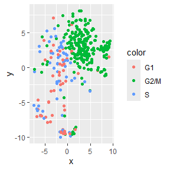

```r
label_phase_ <- label_phase
label_phase_[label_phase=="unclear"] <- NA

tsne_data <- data.frame(cbind(tsne_result$Y,label_phase_))
colnames(tsne_data) <- c("x","y","color")
tsne_data$x <- as.numeric(tsne_data$x)
tsne_data$y <- as.numeric(tsne_data$y)

ggplot()+geom_point(data=tsne_data[index,],aes(x=x,y=y,color=color))
```

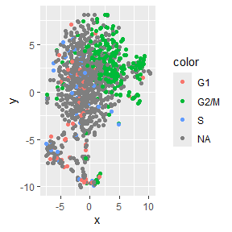

```r
ggplot()+geom_point(data=tsne_data,aes(x=x,y=y,color=color))
```

```r
#arrow.scale=5; cell.alpha=0.4; cell.cex=1; fig.height=4;
emb_tsne_OR_intersect <- tsne_result$Y
rownames(emb_tsne_OR_intersect) <- colnames(res[[3]][["current"]]$OR)

library(VeloRM)
arrow.scale=5; cell.alpha=0.4; cell.cex=1; fig.height=4;
vis_tsne_OR_emb_OR_log_index <- show.velocity.on.embedding.cor(emb_tsne_OR_intersect,
             res[[3]][["current"]]$OR[index_site_name_int_intersect,index],
             res[[3]][["projected"]]$OR[index_site_name_int_intersect,index],
             res[[3]][["delta"]]$OR[index_site_name_int_intersect,index],
             cell.colors=label_phase[index],n=30,scale='log',
             cex=cell.cex,arrow.scale=arrow.scale,arrow.lwd=0.5)
```

```
#> delta projections ... log knn ... transition probs ... done
#> calculating arrows ... done
```

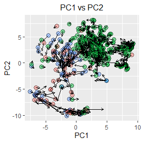

```r
vis_tsne_OR_emb_OR_log_index[[1]]
```

```r
arrow.scale=3;
vis_tsne_OR_emb_OR_log_index_grid <- show.velocity.on.embedding.cor(emb_tsne_OR_intersect,
             res[[3]][["current"]]$OR[index_site_name_int_intersect,index],
             res[[3]][["projected"]]$OR[index_site_name_int_intersect,index],
             res[[3]][["delta"]]$OR[index_site_name_int_intersect,index],
             cell.colors=label_phase[index],n=30,scale='log',
             cex=cell.cex,arrow.scale=arrow.scale,arrow.lwd=0.5,show.grid.flow = TRUE,grid.n = 12)
```

```
#> delta projections ... log knn ... transition probs ... done
#> calculating arrows ... done
#> grid estimates ... grid.sd= 1.129561  min.arrow.size= 0.02259122  max.grid.arrow.length= 0.04391434  done
```

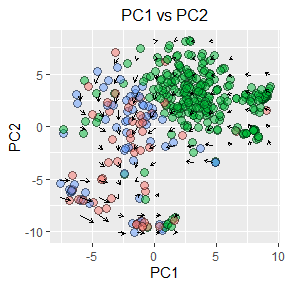

```r
vis_tsne_OR_emb_OR_log_index_grid[[1]]
```

```r
# saveRDS(emb_tsne_OR_intersect,"D:/data/VeloRM_data/scDART-seq/results/cell_cycle_sites/emb_tsne_OR_intersect.rds")
# saveRDS(vis_tsne_OR_emb_OR_log_index,"D:/data/VeloRM_data/scDART-seq/results/cell_cycle_sites/vis_tsne_OR_emb_OR_log_index.rds")
# saveRDS(vis_tsne_OR_emb_OR_log_index_grid,"D:/data/VeloRM_data/scDART-seq/results/cell_cycle_sites/vis_tsne_OR_emb_OR_log_index_grid.rds")
```

##### OR embedding UMAP

```r
library(uwot)
label_phase_ <- label_phase
label_phase_[label_phase=="unclear"] <- NA
# Run UMAP
umap_result <- umap(t(res[[3]][["current"]]$OR[index_site_name_int_intersect,]),n_neighbors=30,min_dist=1.5,seed=42,pca=5)

# View UMAP embeddings
head(umap_result)
```

```
#>                  [,1]       [,2]
#> YTHcell_1   -2.963754  2.6934097
#> YTHcell_10   4.746024  0.1502007
#> YTHcell_100 -8.001254 -0.9895649
#> YTHcell_101 -3.435539 -6.7393263
#> YTHcell_102 -1.288628 -1.8874463
#> YTHcell_103 -3.433725  1.0604286
```

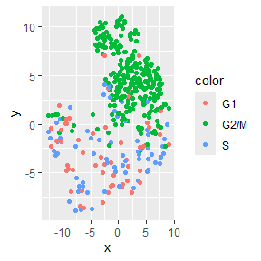

```r
umap_data <- data.frame(cbind(umap_result,label_phase_))
colnames(umap_data) <- c("x","y","color")
umap_data$x <- as.numeric(umap_data$x)
umap_data$y <- as.numeric(umap_data$y)

ggplot()+geom_point(data=umap_data[index,],aes(x=x,y=y,color=color))
```

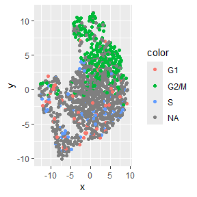

```r
ggplot()+geom_point(data=umap_data,aes(x=x,y=y,color=color))
```

```r
emb_umap_OR_intersect <- umap_result
rownames(emb_umap_OR_intersect) <- colnames(res[[3]][["current"]]$OR)

library(VeloRM)
arrow.scale=5; cell.alpha=0.4; cell.cex=1; fig.height=4;
vis_umap_OR_emb_OR_log_index <- show.velocity.on.embedding.cor(emb_umap_OR_intersect,
             res[[3]][["current"]]$OR[index_site_name_int_intersect,index],
             res[[3]][["projected"]]$OR[index_site_name_int_intersect,index],
             res[[3]][["delta"]]$OR[index_site_name_int_intersect,index],
             cell.colors=label_phase[index],n=30,scale='log',
             cex=cell.cex,arrow.scale=arrow.scale,arrow.lwd=0.5)
```

```
#> delta projections ... log knn ... transition probs ... done
#> calculating arrows ... done
```

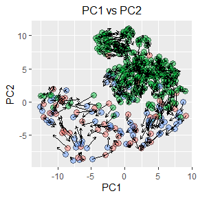

```r
vis_umap_OR_emb_OR_log_index[[1]]
```

```r
arrow.scale=5
vis_umap_OR_emb_OR_log_index_grid <- show.velocity.on.embedding.cor(emb_umap_OR_intersect,
             res[[3]][["current"]]$OR[index_site_name_int_intersect,index],
             res[[3]][["projected"]]$OR[index_site_name_int_intersect,index],
             res[[3]][["delta"]]$OR[index_site_name_int_intersect,index],
             cell.colors=label_phase[index],n=30,scale='log',
             cex=cell.cex,arrow.scale=arrow.scale,arrow.lwd=0.5,show.grid.flow = TRUE,grid.n = 11)
```

```
#> delta projections ... log knn ... transition probs ... done
#> calculating arrows ... done
#> grid estimates ... grid.sd= 1.484204  min.arrow.size= 0.02968408  max.grid.arrow.length= 0.04790656  done
```

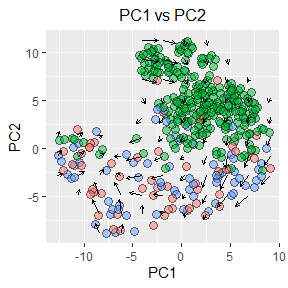

```r
vis_umap_OR_emb_OR_log_index_grid[[1]]
```

```r
# saveRDS(emb_umap_OR_intersect,"D:/data/VeloRM_data/scDART-seq/results/cell_cycle_sites/emb_umap_OR_intersect.rds")
# saveRDS(vis_umap_OR_emb_OR_log_index,"D:/data/VeloRM_data/scDART-seq/results/cell_cycle_sites/vis_umap_OR_emb_OR_log_index.rds")
# saveRDS(vis_umap_OR_emb_OR_log_index_grid,"D:/data/VeloRM_data/scDART-seq/results/cell_cycle_sites/vis_umap_OR_emb_OR_log_index_grid.rds")
```

#### diffusion

##### tsne

```r
library(VeloRM)
# read the velocity results
res <- readRDS("D:/data/VeloRM_data/scDART-seq/results/cell_1_site_1_delta_0.01/res.rds")

# read the visulaization results
vis_tsne_OR_emb_OR_log_index <- readRDS("D:/data/VeloRM_data/scDART-seq/results/cell_cycle_sites/vis_tsne_OR_emb_OR_log_index.rds")
vis_tsne_OR_emb_OR_log_index <- vis_tsne_OR_emb_OR_log_index[[2]]

# read the embedding
emb_tsne_OR_intersect <- readRDS("D:/data/VeloRM_data/scDART-seq/results/cell_cycle_sites/emb_tsne_OR_intersect.rds")

# read the name of the sites
index_site_name_int_intersect <- readRDS("D:/data/VeloRM_data/scDART-seq/results/cell_cycle_sites/index_site_name_int_intersect.rds")


# read the cell label
label_SigRM <- readRDS("D:/data/VeloRM_data/scDART-seq/origin/label_SigRM.rds")

label_phase <- rep(NA,1209)
names(label_phase) <- colnames(res[[1]][["conv.nmat.norm"]])

label_phase[names(label_SigRM)] <- label_SigRM
index <- which(label_phase=="G1"|label_phase=="G2/M"|label_phase=="S")

diffusion_density_plot_tsne <- diffusion_density_plot(emb_tsne_OR_intersect[index,],vis_tsne_OR_emb_OR_log_index$tp,forward = TRUE,2500,scale="log")
# saveRDS(diffusion_density_plot_tsne,"D:/data/VeloRM_data/scDART-seq/results/cell_cycle_sites/diffusion_density_plot_tsne.rds")
```

###### visulization

```r
diffusion_density_plot_tsne <- readRDS("D:/data/VeloRM_data/scDART-seq/results/cell_cycle_sites/diffusion_density_plot_tsne.rds")
diffusion_density_plot_tsne
```

```
#> $data
#>                     dim1         dim2    density
#> YTHcell_102  -2.26906992  -0.59938883  -3.646583
#> YTHcell_104   2.30769973   3.11415627  -6.226438
#> YTHcell_108  -5.67454210   4.37130169 -10.906267
#> YTHcell_11    5.86658387   3.83448178 -10.111560
#> YTHcell_111   0.66172056  -9.72356036  -4.530197
#> YTHcell_112  -3.48904150   2.10548758  -6.122677
#> YTHcell_119   3.07559419   1.35328763  -8.307648
#> YTHcell_12    5.10893471  -0.38356851 -10.263097
#> YTHcell_129   3.86097547   3.16470292  -9.309923
#> YTHcell_130   3.07771633   4.49398620  -9.625450
#> YTHcell_133   2.02121761   1.80367383  -6.357537
#> YTHcell_134   4.60066685   1.93340452  -8.463816
#> YTHcell_135   0.89439569   2.10319866  -6.594919
#> YTHcell_138   8.99360245   3.12503018  -7.730954
#> YTHcell_14    3.05190565   4.80326594  -7.476008
#> YTHcell_140   1.36626543  -0.73354563  -5.931017
#> YTHcell_143   4.36143766   2.48283836  -9.117728
#> YTHcell_145   2.96293597   6.73265908  -9.351358
#> YTHcell_146   2.76663776   4.01006783  -6.975943
#> YTHcell_148  -6.74841572  -6.23780513  -6.937099
#> YTHcell_15   -3.95457117   0.65746375  -5.160766
#> YTHcell_150  -6.59272811  -4.69220903  -8.547334
#> YTHcell_154   0.13861136   2.81751444  -8.640040
#> YTHcell_162   3.82463752   3.33741543  -8.977169
#> YTHcell_164   2.46314707   4.03683292  -8.302994
#> YTHcell_170  -0.94388040  -0.43785566  -4.278992
#> YTHcell_172   6.62051048   2.67276579  -8.975931
#> YTHcell_174   1.34918177   2.70776369  -5.629932
#> YTHcell_176   5.07801728   3.52941022  -8.898938
#> YTHcell_183   2.55318215   2.91681508  -7.095590
#> YTHcell_184   0.95448088   5.08462444 -10.433774
#> YTHcell_189   3.44385443   0.73142645  -8.743130
#> YTHcell_190   4.45057862   4.32333065  -9.845091
#> YTHcell_196   1.01454722   4.90501663  -9.016428
#> YTHcell_197   8.79629001   2.57786259  -9.515844
#> YTHcell_202   3.08264822  -1.55575637  -8.549500
#> YTHcell_203   8.02434995  -0.35545789 -11.198868
#> YTHcell_205   1.11890849   2.75725035  -6.628647
```

[output cut: 526 more lines]

```
#> $labels$title
#> [1] "forward"
#>
#> $labels$x
#> [1] "dim1"
#>
#> $labels$y
#> [1] "dim2"
#>
#> $labels$colour
#> [1] "density"
#>
#>
#> attr(,"class")
#> [1] "gg"     "ggplot"
```

##### umap

```r
library(VeloRM)
# read the velocity results
res <- readRDS("D:/data/VeloRM_data/scDART-seq/results/cell_1_site_1_delta_0.01/res.rds")

# read the visulaization results
vis_umap_OR_emb_OR_log_index <- readRDS("D:/data/VeloRM_data/scDART-seq/results/cell_cycle_sites/vis_umap_OR_emb_OR_log_index.rds")
vis_umap_OR_emb_OR_log_index <- vis_umap_OR_emb_OR_log_index[[2]]

# read the embedding
emb_umap_OR_intersect <- readRDS("D:/data/VeloRM_data/scDART-seq/results/cell_cycle_sites/emb_umap_OR_intersect.rds")

# read the name of the sites
index_site_name_int_intersect <- readRDS("D:/data/VeloRM_data/scDART-seq/results/cell_cycle_sites/index_site_name_int_intersect.rds")


# read the cell label
label_SigRM <- readRDS("D:/data/VeloRM_data/scDART-seq/origin/label_SigRM.rds")

label_phase <- rep(NA,1209)
names(label_phase) <- colnames(res[[1]][["conv.nmat.norm"]])

label_phase[names(label_SigRM)] <- label_SigRM
index <- which(label_phase=="G1"|label_phase=="G2/M"|label_phase=="S")

diffusion_density_plot_umap <- diffusion_density_plot(emb_umap_OR_intersect[index,],vis_umap_OR_emb_OR_log_index$tp,forward = TRUE,2500,scale="log")
# saveRDS(diffusion_density_plot_umap,"D:/data/VeloRM_data/scDART-seq/results/cell_cycle_sites/diffusion_density_plot_umap.rds")
```

###### visulization

```r
diffusion_density_plot_umap <- readRDS("D:/data/VeloRM_data/scDART-seq/results/cell_cycle_sites/diffusion_density_plot_umap.rds")
diffusion_density_plot_umap
```

```
#> $data
#>                       dim1        dim2    density
#> YTHcell_102   -1.288628091 -1.88744625  -6.068274
#> YTHcell_104    2.632844220  2.02147314  -6.211069
#> YTHcell_108    0.474335919  2.74130389  -6.781474
#> YTHcell_11     3.903827439  6.31569216  -9.313811
#> YTHcell_111  -12.673458328 -0.78373259  -3.836615
#> YTHcell_112    3.864017735 -4.80258968  -7.134119
#> YTHcell_119    5.485724698  4.48172352  -8.311131
#> YTHcell_12     1.733013879  5.74435064  -6.982775
#> YTHcell_129    5.331704865  5.10367796  -9.114395
#> YTHcell_130    3.921453725  3.88082096  -9.075981
#> YTHcell_133    6.947690259  1.52693770  -7.096688
#> YTHcell_134    1.556411277  6.45402309  -7.846006
#> YTHcell_135    7.153599988 -0.23480484  -7.619920
#> YTHcell_138   -1.652847220  9.12900326  -8.954896
#> YTHcell_14     0.671033631  2.83217356  -5.376425
#> YTHcell_140    6.620217572 -1.01393417  -6.302542
#> YTHcell_143    7.216634522  4.79320976  -9.339764
#> YTHcell_145    0.122848581  4.54247591  -6.018280
#> YTHcell_146    2.273934375  4.23988030  -6.090546
#> YTHcell_148   -7.246940364 -6.94093397  -8.023738
#> YTHcell_15    -0.183552016  0.83882925  -5.181841
#> YTHcell_150   -2.841656675 -8.00745085  -8.353916
#> YTHcell_154    9.003766785  1.61263010 -10.690371
#> YTHcell_162    6.960123311  3.62626097  -9.190970
#> YTHcell_164    3.140343915  4.60076544  -6.169356
#> YTHcell_170    0.612514268 -6.50569513  -7.212870
#> YTHcell_172    2.120157014  6.46843550  -6.843632
#> YTHcell_174    6.414977322 -0.70829548  -7.157160
#> YTHcell_176    1.916539918  3.20047972  -6.815502
#> YTHcell_183    5.141611825  4.22778770  -6.134295
#> YTHcell_184    2.249285947  3.17145464  -8.160435
#> YTHcell_189    5.006482850  6.28529665  -9.275100
#> YTHcell_190   -1.567434479  3.52814266  -7.572840
#> YTHcell_196    7.589433442  3.13566324  -8.723962
#> YTHcell_197   -2.315470089  7.88633129 -10.420262
#> YTHcell_202    5.687954674  2.65298268  -6.629479
#> YTHcell_203   -0.196568658 10.32611534  -9.984323
#> YTHcell_205    5.434313069  0.73165557  -7.246174
```

[output cut: 526 more lines]

```
#> $labels$title
#> [1] "forward"
#>
#> $labels$x
#> [1] "dim1"
#>
#> $labels$y
#> [1] "dim2"
#>
#> $labels$colour
#> [1] "density"
#>
#>
#> attr(,"class")
#> [1] "gg"     "ggplot"
```

#### site analysis 1

chr5: 69174992 CCNB1 +

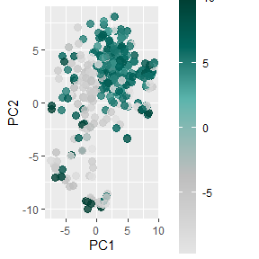

```r
median_OR <- apply(res[[3]][["current"]][["OR"]][index_site_name_int_intersect,index],1,median)

ind <- which.max(median_OR)

data_tsne=tsne_data[index,1:2]
data_tsne$OR = res[[3]][["current"]][["OR"]][index_site_name_int_intersect[ind],index]
plot_tsne_site120 <- ggplot() +
  geom_point(data = data_tsne, aes(x = x, y = y, color = OR), size = 3, alpha = 0.8) +
  scale_color_gradientn(
    colors = c("grey90", "grey", "#5AB4AC", "#01665E", "#003C30"),
    values = scales::rescale(c(0, 0.3, 0.6, 0.8, 1)),
    limits = c(min(data_tsne$OR), max(data_tsne$OR)),
    name = "Odds Ratio",
    guide = guide_colorbar(barwidth = 1, barheight = 15)
  ) +
  labs(title = NULL)+xlab("PC1")+ylab("PC2")

data_umap=umap_data[index,1:2]
data_umap$OR = res[[3]][["current"]][["OR"]][index_site_name_int_intersect[ind],index]
plot_tsne_site120
```

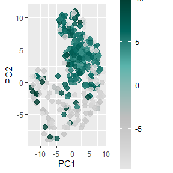

```r
plot_umap_site120 <- ggplot() +
  geom_point(data = data_umap, aes(x = x, y = y, color = OR), size = 3, alpha = 0.8) +
  scale_color_gradientn(
    colors = c("grey90", "grey", "#5AB4AC", "#01665E", "#003C30"),
    values = scales::rescale(c(0, 0.3, 0.6, 0.8, 1)),
    limits = c(min(data_umap$OR), max(data_umap$OR)),
    name = "Odds Ratio",
    guide = guide_colorbar(barwidth = 1, barheight = 15)
  ) +
  labs(title = NULL)+xlab("PC1")+ylab("PC2")
plot_umap_site120
```

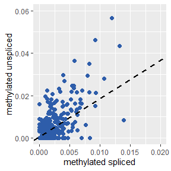

```r
data <- as.data.frame(cbind(res[[1]][["conv.emat.norm"]][index_site_name_int_intersect[ind],index],
              res[[1]][["conv.nmat.norm"]][index_site_name_int_intersect[ind],index],
              tsne_data [index,3]))
colnames(data) <- c("x","y","color")
data$x <- as.numeric(data$x)
data$y <- as.numeric(data$y)

slope <- res[[1]][["gamma"]][index_site_name_int_intersect[ind]]
intercept <- res[[1]][["ko"]][index_site_name_int_intersect[ind],1]

plot_site120_meth <- ggplot()+geom_point(data=data,aes(x=x,y=y),size=2,color="#2E5DAA") +
  geom_abline(slope = slope, intercept = intercept, color = "black", size = 1,linetype = "dashed")+
  coord_cartesian(xlim = c(0,0.02),ylim = c(0,0.06))+ylab("methylated unspliced")+xlab("methylated spliced")
plot_site120_meth
```

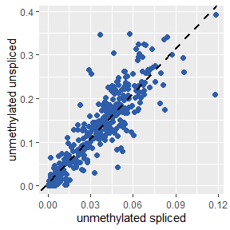

```r
data <- as.data.frame(cbind(res[[2]][["conv.emat.norm"]][index_site_name_int_intersect[ind],index],
              res[[2]][["conv.nmat.norm"]][index_site_name_int_intersect[ind],index],
              tsne_data [index,3]))
colnames(data) <- c("x","y","color")
data$x <- as.numeric(data$x)
data$y <- as.numeric(data$y)
slope <- res[[2]][["gamma"]][index_site_name_int_intersect[ind]]
intercept <- res[[2]][["ko"]][index_site_name_int_intersect[ind],1]

plot_site120_unmeth <- ggplot()+geom_point(data=data,aes(x=x,y=y),size=2,color="#2E5DAA") +
  geom_abline(slope = slope, intercept = intercept, color = "black", size = 1,linetype = "dashed")+ylab("unmethylated unspliced")+xlab("unmethylated spliced")
plot_site120_unmeth
```

```r
unspliced_M_current <- log2(((res[[1]][["conv.nmat.norm"]][index_site_name_int_intersect[ind],index]+1e-7)/
  (res[[2]][["conv.nmat.norm"]][index_site_name_int_intersect[ind],index]+1e-7))/res[[4]][["control_information_Beta"]][index_site_name_int_intersect[ind]])

spliced_M_current <- log2(((res[[1]][["conv.emat.norm"]][index_site_name_int_intersect[ind],index]+1e-7)/
                           (res[[2]][["conv.emat.norm"]][index_site_name_int_intersect[ind],index]+1e-7))/res[[4]][["control_information_Beta"]][index_site_name_int_intersect[ind]])

data <- as.data.frame(cbind(spliced_M_current,
                            unspliced_M_current,
                            tsne_data [index,3]))
colnames(data) <- c("x","y","color")
data$x <- as.numeric(data$x)
data$y <- as.numeric(data$y)

threshold <- 0

data_steady <- data[which(data$x*data$y>threshold^2),]
lm_res <- lm(y~x,data_steady)
lm_res$coefficients
```

```
#> (Intercept)           x
#>  -0.8422188   1.1035520
```

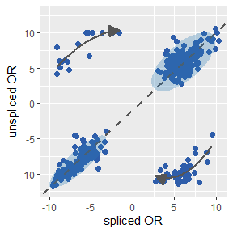

```r
slope <- lm_res$coefficients[2]
intercept <- lm_res$coefficients[1]

data_steady_left <- data[which(data$x<threshold&data$y<threshold),]
data_steady_right <- data[which(data$x>threshold&data$y>threshold),]

data_left <- data[which(data$x<threshold&data$y>threshold),]
data_right <- data[which(data$x>threshold&data$y<threshold),]


residuals_value_left <- predict(lm_res,data_left)-data_left$y
residuals_value_right <- predict(lm_res,data_right)-data_right$y

library(ggforce)
plot_site120_OR <- ggplot()+geom_point(data=data,aes(x=x,y=y),size=2,color="#2E5DAA") +
  geom_abline(slope = slope, intercept = intercept, color = "#555555", size = 1,linetype = "dashed")+
  geom_line(
    stat = "smooth",
    data = data_left,
    aes(x = x, y = y),
    method = "lm",
    formula = y ~ poly(x, 2),
    color = "#555555",
    size = 1,
    arrow = arrow(type = "closed", length = unit(0.15, "inches"))
  )+geom_line(
    stat = "smooth",
    data = data_right,
    aes(x = x, y = y),
    method = "lm",
    formula = y ~ poly(x, 2),
    color = "#555555",
    size = 1,
    arrow = arrow(type = "closed", length = unit(0.15, "inches"), ends = "first")
  )+stat_ellipse(data = data_steady_left, level = 0.95, linetype = 1, size = 2,
    fill = "#2C7BB6",
                 aes(x = x, y = y), alpha = 0.3, segments = 50, geom = "polygon",type = "t") +stat_ellipse(data = data_steady_right, level = 0.99, linetype = 1, size = 2,
               fill = "#2C7BB6",  aes(x = x, y = y), alpha = 0.3, segments = 50, geom = "polygon",type = "t") +ylab("unspliced OR")+xlab("spliced OR")
plot_site120_OR
```

#### site analysis 2

chr20: 5115239 PCNA -

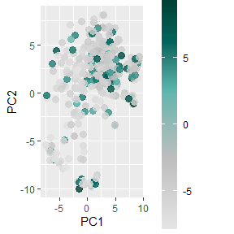

```r
ind <- 24

data=tsne_data[index,1:2]
data$OR = res[[3]][["current"]][["OR"]][index_site_name_int_intersect[ind],index]

plot_tsne_site24 <- ggplot() +
  geom_point(data = data, aes(x = x, y = y, color = OR), size = 3, alpha = 0.8) +
  scale_color_gradientn(
    colors = c("grey90", "grey", "#5AB4AC", "#01665E", "#003C30"),
    values = scales::rescale(c(0, 0.3, 0.6, 0.8, 1)),
    limits = c(min(data$OR), max(data$OR)),
    name = "Odds Ratio",
    guide = guide_colorbar(barwidth = 1, barheight = 15)
  ) +
  labs(title = NULL)+xlab("PC1")+ylab("PC2")

data=umap_data[index,1:2]
data$OR = res[[3]][["current"]][["OR"]][index_site_name_int_intersect[ind],index]
plot_tsne_site24
```

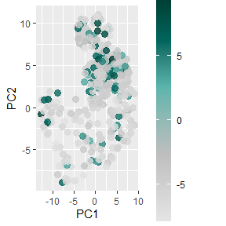

```r
plot_umap_site24 <- ggplot() +
  geom_point(data = data, aes(x = x, y = y, color = OR), size = 3, alpha = 0.8) +
  scale_color_gradientn(
    colors = c("grey90", "grey", "#5AB4AC", "#01665E", "#003C30"),
    values = scales::rescale(c(0, 0.3, 0.6, 0.8, 1)),
    limits = c(min(data$OR), max(data$OR)),
    name = "Odds Ratio",
    guide = guide_colorbar(barwidth = 1, barheight = 15)
  ) +
  labs(title = NULL)+xlab("PC1")+ylab("PC2")
plot_umap_site24
```

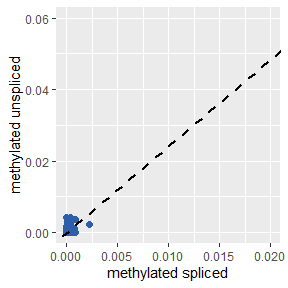

```r
data <- as.data.frame(cbind(res[[1]][["conv.emat.norm"]][index_site_name_int_intersect[ind],index],
              res[[1]][["conv.nmat.norm"]][index_site_name_int_intersect[ind],index],
              tsne_data [index,3]))
colnames(data) <- c("x","y","color")
data$x <- as.numeric(data$x)
data$y <- as.numeric(data$y)

slope <- res[[1]][["gamma"]][index_site_name_int_intersect[ind]]
intercept <- res[[1]][["ko"]][index_site_name_int_intersect[ind],1]

plot_site24_meth <- ggplot()+geom_point(data=data,aes(x=x,y=y),size=2,color="#2E5DAA") +
  geom_abline(slope = slope, intercept = intercept, color = "black", size = 1,linetype = "dashed")+
  coord_cartesian(xlim = c(0,0.02),ylim = c(0,0.06))+ylab("methylated unspliced")+xlab("methylated spliced")
plot_site24_meth
```

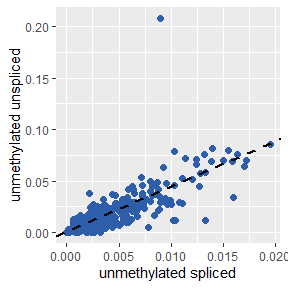

```r
data <- as.data.frame(cbind(res[[2]][["conv.emat.norm"]][index_site_name_int_intersect[ind],index],
              res[[2]][["conv.nmat.norm"]][index_site_name_int_intersect[ind],index],
              tsne_data [index,3]))
colnames(data) <- c("x","y","color")
data$x <- as.numeric(data$x)
data$y <- as.numeric(data$y)
slope <- res[[2]][["gamma"]][index_site_name_int_intersect[ind]]
intercept <- res[[2]][["ko"]][index_site_name_int_intersect[ind],1]

plot_site24_unmeth <- ggplot()+geom_point(data=data,aes(x=x,y=y),size=2,color="#2E5DAA") +
  geom_abline(slope = slope, intercept = intercept, color = "black", size = 1,linetype = "dashed")+ylab("unmethylated unspliced")+xlab("unmethylated spliced")
plot_site24_unmeth
```

```r
unspliced_M_current <- log2(((res[[1]][["conv.nmat.norm"]][index_site_name_int_intersect[ind],index]+1e-7)/
  (res[[2]][["conv.nmat.norm"]][index_site_name_int_intersect[ind],index]+1e-7))/res[[4]][["control_information_Beta"]][index_site_name_int_intersect[ind]])

spliced_M_current <- log2(((res[[1]][["conv.emat.norm"]][index_site_name_int_intersect[ind],index]+1e-7)/
                           (res[[2]][["conv.emat.norm"]][index_site_name_int_intersect[ind],index]+1e-7))/res[[4]][["control_information_Beta"]][index_site_name_int_intersect[ind]])

data <- as.data.frame(cbind(spliced_M_current,
                            unspliced_M_current,
                            tsne_data [index,3]))
colnames(data) <- c("x","y","color")
data$x <- as.numeric(data$x)
data$y <- as.numeric(data$y)

threshold <- 0

data_steady <- data[which(data$x*data$y>threshold^2),]
lm_res <- lm(y~x,data_steady)
lm_res$coefficients
```

```
#> (Intercept)           x
#>  -0.9779591   1.1841829
```

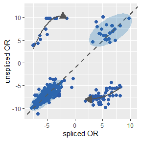

```r
slope <- lm_res$coefficients[2]
intercept <- lm_res$coefficients[1]

data_steady_left <- data[which(data$x<threshold&data$y<threshold),]
data_steady_right <- data[which(data$x>threshold&data$y>threshold),]

data_left <- data[which(data$x<threshold&data$y>threshold),]
data_right <- data[which(data$x>threshold&data$y<threshold),]


residuals_value_left <- predict(lm_res,data_left)-data_left$y
residuals_value_right <- predict(lm_res,data_right)-data_right$y

library(ggforce)
plot_site24_OR <- ggplot()+geom_point(data=data,aes(x=x,y=y),size=2,color="#2E5DAA") +
  geom_abline(slope = slope, intercept = intercept, color = "#555555", size = 1,linetype = "dashed")+
  geom_line(
    stat = "smooth",
    data = data_left,
    aes(x = x, y = y),
    method = "lm",
    formula = y ~ poly(x, 2),
    color = "#555555",
    size = 1,
    arrow = arrow(type = "closed", length = unit(0.15, "inches"))
  )+geom_line(
    stat = "smooth",
    data = data_right,
    aes(x = x, y = y),
    method = "lm",
    formula = y ~ poly(x, 2),
    color = "#555555",
    size = 1,
    arrow = arrow(type = "closed", length = unit(0.15, "inches"), ends = "first")
  )+stat_ellipse(data = data_steady_left, level = 0.99, linetype = 1, size = 2,
    fill = "#2C7BB6",
                 aes(x = x, y = y), alpha = 0.3, segments = 50, geom = "polygon",type = "t") +stat_ellipse(data = data_steady_right, level = 0.9, linetype = 1, size = 2,
               fill = "#2C7BB6",  aes(x = x, y = y), alpha = 0.3, segments = 50, geom = "polygon",type = "t") +ylab("unspliced OR")+xlab("spliced OR")
plot_site24_OR
```

#### site analysis 3

chr5: 69174989 CCNB1 +

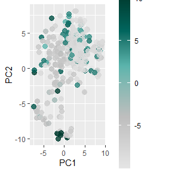

```r
ind <- 119

data=tsne_data[index,1:2]
data$OR = res[[3]][["current"]][["OR"]][index_site_name_int_intersect[ind],index]

plot_tsne_site119 <- ggplot() +
  geom_point(data = data, aes(x = x, y = y, color = OR), size = 3, alpha = 0.8) +
  scale_color_gradientn(
    colors = c("grey90", "grey", "#5AB4AC", "#01665E", "#003C30"),
    values = scales::rescale(c(0, 0.3, 0.6, 0.8, 1)),
    limits = c(min(data$OR), max(data$OR)),
    name = "Odds Ratio",
    guide = guide_colorbar(barwidth = 1, barheight = 15)
  ) +
  labs(title = NULL)+xlab("PC1")+ylab("PC2")

data=umap_data[index,1:2]
data$OR = res[[3]][["current"]][["OR"]][index_site_name_int_intersect[ind],index]
plot_tsne_site119
```

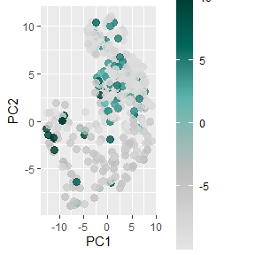

```r
plot_umap_site119 <- ggplot() +
  geom_point(data = data, aes(x = x, y = y, color = OR), size = 3, alpha = 0.8) +
  scale_color_gradientn(
    colors = c("grey90", "grey", "#5AB4AC", "#01665E", "#003C30"),
    values = scales::rescale(c(0, 0.3, 0.6, 0.8, 1)),
    limits = c(min(data$OR), max(data$OR)),
    name = "Odds Ratio",
    guide = guide_colorbar(barwidth = 1, barheight = 15)
  ) +
  labs(title = NULL)+xlab("PC1")+ylab("PC2")
plot_umap_site119
```

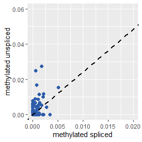

```r
data <- as.data.frame(cbind(res[[1]][["conv.emat.norm"]][index_site_name_int_intersect[ind],index],
              res[[1]][["conv.nmat.norm"]][index_site_name_int_intersect[ind],index],
              tsne_data [index,3]))
colnames(data) <- c("x","y","color")
data$x <- as.numeric(data$x)
data$y <- as.numeric(data$y)

slope <- res[[1]][["gamma"]][index_site_name_int_intersect[ind]]
intercept <- res[[1]][["ko"]][index_site_name_int_intersect[ind],1]

plot_site119_meth <- ggplot()+geom_point(data=data,aes(x=x,y=y),size=2,color="#2E5DAA") +
  geom_abline(slope = slope, intercept = intercept, color = "black", size = 1,linetype = "dashed")+
  coord_cartesian(xlim = c(0,0.02),ylim = c(0,0.06))+ylab("methylated unspliced")+xlab("methylated spliced")
plot_site119_meth
```

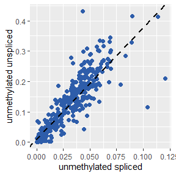

```r
data <- as.data.frame(cbind(res[[2]][["conv.emat.norm"]][index_site_name_int_intersect[ind],index],
              res[[2]][["conv.nmat.norm"]][index_site_name_int_intersect[ind],index],
              tsne_data [index,3]))
colnames(data) <- c("x","y","color")
data$x <- as.numeric(data$x)
data$y <- as.numeric(data$y)
slope <- res[[2]][["gamma"]][index_site_name_int_intersect[ind]]
intercept <- res[[2]][["ko"]][index_site_name_int_intersect[ind],1]

plot_site119_unmeth <- ggplot()+geom_point(data=data,aes(x=x,y=y),size=2,color="#2E5DAA") +
  geom_abline(slope = slope, intercept = intercept, color = "black", size = 1,linetype = "dashed")+ylab("unmethylated unspliced")+xlab("unmethylated spliced")
plot_site119_unmeth
```

```r
unspliced_M_current <- log2(((res[[1]][["conv.nmat.norm"]][index_site_name_int_intersect[ind],index]+1e-7)/
  (res[[2]][["conv.nmat.norm"]][index_site_name_int_intersect[ind],index]+1e-7))/res[[4]][["control_information_Beta"]][index_site_name_int_intersect[ind]])

spliced_M_current <- log2(((res[[1]][["conv.emat.norm"]][index_site_name_int_intersect[ind],index]+1e-7)/
                           (res[[2]][["conv.emat.norm"]][index_site_name_int_intersect[ind],index]+1e-7))/res[[4]][["control_information_Beta"]][index_site_name_int_intersect[ind]])

data <- as.data.frame(cbind(spliced_M_current,
                            unspliced_M_current,
                            tsne_data [index,3]))
colnames(data) <- c("x","y","color")
data$x <- as.numeric(data$x)
data$y <- as.numeric(data$y)

threshold <- 0

data_steady <- data[which(data$x*data$y>threshold^2),]
lm_res <- lm(y~x,data_steady)
lm_res$coefficients
```

```
#> (Intercept)           x
#>  -0.8828087   1.1420673
```

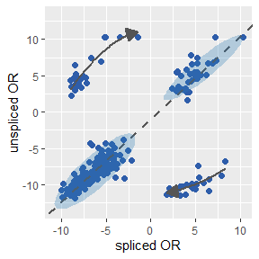

```r
slope <- lm_res$coefficients[2]
intercept <- lm_res$coefficients[1]

data_steady_left <- data[which(data$x>-8&data$x<threshold&data$y<threshold),]
data_steady_right <- data[which(data$x>threshold&data$y>threshold),]

data_left <- data[which(data$x<threshold&data$y>threshold),]
data_right <- data[which(data$x>threshold&data$y<threshold),]


residuals_value_left <- predict(lm_res,data_left)-data_left$y
residuals_value_right <- predict(lm_res,data_right)-data_right$y

library(ggforce)
plot_site119_OR <- ggplot()+geom_point(data=data,aes(x=x,y=y),size=2,color="#2E5DAA") +
  geom_abline(slope = slope, intercept = intercept, color = "#555555", size = 1,linetype = "dashed")+
  geom_line(
    stat = "smooth",
    data = data_left,
    aes(x = x, y = y),
    method = "lm",
    formula = y ~ poly(x, 2),
    color = "#555555",
    size = 1,
    arrow = arrow(type = "closed", length = unit(0.15, "inches"))
  )+geom_line(
    stat = "smooth",
    data = data_right,
    aes(x = x, y = y),
    method = "lm",
    formula = y ~ poly(x, 2),
    color = "#555555",
    size = 1,
    arrow = arrow(type = "closed", length = unit(0.15, "inches"), ends = "first")
  )+stat_ellipse(data = data_steady_left, level = 0.999, linetype = 1, size = 2,
    fill = "#2C7BB6",
                 aes(x = x, y = y), alpha = 0.3, segments = 50, geom = "polygon",type = "t") +stat_ellipse(data = data_steady_right, level = 0.8, linetype = 1, size = 2,
               fill = "#2C7BB6",  aes(x = x, y = y), alpha = 0.3, segments = 50, geom = "polygon",type = "t") +ylab("unspliced OR")+xlab("spliced OR")
plot_site119_OR
```

### scVelo

jupyter notebook is in figshare: https://doi.org/10.6084/m9.figshare.28955183 or https://github.com/whz991026/VeloRM